# Pycon Korea 2017

## 캐글(Kaggle) 뉴욕시 임대 아파트 문제 머신러닝 튜토리얼

[figure not shown]

### 일시 : 2017년 8월 15일, 시간 오전 10시 ~ 오후 2시

### 장소 : 코엑스 그랜드볼륨 2층

### 링크 : https://www.pycon.kr/2017/program/tutorial/1

### 온오프믹스 : https://onoffmix.com/event/107250

### 캐글뽀개기 스터디 : https://www.facebook.com/groups/kagglebreak

## 튜토리얼 목차

### 발표 시간

### 튜토리얼 내용

10:00 ~ 10:50

(첫 번째 시간) 캐글 및 문제 소개

11:00 ~ 11:50

(두 번째 시간) AWS 세팅하기 및 데이터 탐색

12:00 ~ 12:50

(세 번째 시간) 변수 구성 및 싱글 모델링

13:00 ~

(네 번째 시간) 메타 모델링 및 식사 시간

- 각 타임 별로 중간에 10분식 쉬겠습니다. 네 번째 시간은 식사 관계로 빨리 끝날 수 있습니다.
- 윈도우 환경에서 xgboost 라이브러리 설치 문제로 aws(아마존 웹 서비스) 세팅을 하겠습니다.
- 두 번째 시간부터 실습이 이루어질 예정입니다. 실습은 파이썬 3.5 버전 이상으로 준비해주세요.

### 자료 링크

- 실습의 해당되는 코드는 github 및 링크를 통해 공유드립니다. github을 clone 또는 download 해주시면 됩니다.
- 워킹캐글(캐글뽀개기 스터디 이름) Github : [Tutorial Github](https://github.com/KaggleBreak/walkingkaggle)
- 자료 링크 : [다운로드](https://www.dropbox.com/s/0ggaqvshr29emzj/pycon2017_kr.zip?dl=0)

### 발표 자료 보는 법 (jupyter notebook)

- jupyter (IPython Notebook)은 쉽게 말하면(*I는 Interactive의 약자), 대화형 파이썬 공책 또는 노트...
  - jupyter Notebook은 live code, equation, visualization, 그리고 explanatory text를 할 수 있는 web application
  - jupyter Notebook에서는 40개의 프로그래밍 언어를 지원하고 있습니다. Python, R, Julia, Scala 등
  - IPython 3.0이상부터는 Jupyter라 불려지므로, 이제부터는 Jupyter Notebook
- pip 업그레이드 방법 : python -m pip install --upgrade pip
  - anaconda가 설치되어있을 경우 터미널(conda cmd)에서 conda install jupyter
  - pip가 설치되어있을 경우 터미널(윈도우 cmd)에서 pip install jupyter (또는 pip3 install jupyter)
- jupyter 정상적인 설치 완료 후, 발표 자료를 다운로드 받은 디렉토리 터미널 창에서 jupyter notebook 실행
  - 명령어를 입력하면 웹브라우저를 통해 Jupyter가 실행됩니다. 실행이 안 될 경우 웹브라우저 주소창에 http://localhost:8888 를 입력.
  - 폴더에서 발표 자료 pycon_korea_2017_kaggle_tutorial.ipynb 파일 클릭

# (첫 번째 시간) 캐글 및 문제 소개

## 1. Kaggle - https://www.kaggle.com

### - [Wikipedia - Kaggle?](https://en.wikipedia.org/wiki/Kaggle)

- Kaggle은 기업 및 연구원이 데이터 및 통계를 게시하고 데이터 마이너가 예측 및 설명을 위한 최상의 모델을 만들기 위해 경쟁하는 예측 모델링 및 분석 경쟁을위한 플랫폼. Crowdsourcing 접근 방식은 예측 모델링 작업에 적용 할 수있는 무수한 전략이 있으며 어떤 기술 또는 분석가가 가장 효과적인지를 처음부터 알 수 없다는 사실에 의존.

## 2. 문제

### - [뉴욕시 임대아파트 문제](https://www.kaggle.com/c/two-sigma-connect-rental-listing-inquiries)

- RentHop은 데이터를 사용하여 임대 목록을 품질 별로 분류하여 아파트 검색을 더 똑똑하게 만드는 사이트
- 완벽한 아파트를 찾긴 어렵지만 사용 가능한 모든 부동산 데이터를 프로그래밍 방식으로 구조화하고 이해하는 것이 더욱 어려움.
- Two Sigma와 RentHop은 이 모집 경쟁에서 비즈니스 가치를 창출하기 위해 캐글러들의 독창적인 엔진을 발휘하도록 초대

[figure not shown]

#### - [Renthop](https://www.renthop.com/)

- RentHop은 사용자가 뉴욕, 보스턴, 시카고 및 다른 대도시 지역의 아파트를 검색 할 수있게 해주는 웹 및 모바일 기반 검색 엔진. 이 사이트는 실시간 리스팅을 제공하며 품질에 따라 아파트를 분류하는 고유 한 정렬 알고리즘을 사용

[figure not shown]

## 데이터 다운로드

- https://www.kaggle.com/c/two-sigma-connect-rental-listing-inquiries/data
- 데이터 다운로드 목록 train.json, test.json, sample_submission.csv
- 이미지 샘플 데이터 및 토렌토는 다운로드 받지 않음

## 3. 일반적인 캐글 접근방법

### - [General Tips for participating Kaggle Competitions, Mark Peng, Taiwan Kaggle Master](https://www.slideshare.net/markpeng/general-tips-for-participating-kaggle-competitions)

[figure not shown]

- 일반적인 캐글의 데이터 셋은 Train set, Test Set으로 나뉨 (Submission 파일이 따로 있음)
- Test Set은 대회 기간 동안 제출하면 채점 용도로 공개되어 있는 Public LB(Leardboard)와 대회 끝난 후 최종 채점을 평가하는 Private LB(Leardboard)가 있음
- 물론 데이터 셋이 일반적이지 않을 수 있음
  - DB 관계도를 주고 직접 구성하라고 하는 경우 (DB 소스를 직접 주거나)
  - 데이터가 커서 접근할 수 있는 클라우드 주소를 주고 해당 클라우드에서 진행하라고 하거나
  - (옵션) 특정 데이터의 사용 유무는 참가자가 정하거나
  - 데이터의 종류는 이미지, 영상, 텍스트, 숫자. 정형 데이터 또는 비정형 데이터 모두 다룰 수 있음.
- 대회의 목적(상금, 직업, 지식 공유...)에 따라서 문제가 달라짐.

[figure not shown]

- 캐글 프로세스는 데이터 분석의 절차 (서비스의 직접 반영하진 않지만, 커뮤니케이션은 포럼의 참가자들과 Kernel에서 Notebook 형태로 공유)
- 1단계 데이터 전처리, 2단계 싱글 모델, 3단계 변수 구성, 4단계 탐색적 자료 분석, 5단계 다양한 모델 구성, 6단계 앙상블, 7단계 예측
- 데이터 전처리
  - 데이터를 (로컬 혹은 서버)에서 읽을 수 있는 사이즈인지? (메모리, 하드)
  - 데이터의 마이그레이션은 어떻게 할 수 있는지?
  - 변수로 구성할 수 있는 데이터와 구성할 수 없는 데이터가 무엇에 있는지?
- 싱글 모델
  - 기본으로 대회에서 제공한 변수 기준으로 1차 모델을 구성
- 변수 구성
  - Submission ID의 추가할 수 있는 변수가 어떤 것이 있을까?
  - 변수 선택, 차원 축소, 중요한 변수 확인 (모델 기반)
  - Single 모델 별로 유용한 변수를 추리는 것. 모델에 걸리는 시간 고려
  - 텍스트 또는 카테고리 변수는 어떻게 활용할 것인지?
- 탐색적 자료 분석
  - 변수들의 데이터의 분포는 어떻게 되는지? (단변량)
  - 변수들간의 관계는 어떻게 되는지? (다변량)
  - 이상치는 어떻게 확인하고 어떤 조치를 취할 수 있는지?
  - 데이터 정규화
  - 어떤 변수를 더 추가할 수 있는지 아이디어 또는 인사이트 발견
- 다양한 모델 구성
  - 문제가 회귀, 분류, 추천 어떤 것을 목적으로 삼고 있는지에 따라 모델 구성이 다름
  - (분류) 로지스틱 회귀모형, Tree 모델, Bayesian 모델, 신경망 모델, Kernel 모델 등 구성 하여 모델 간의 결과 값 기반하여 상관관계 파악
  - 모델들의 다양한 파라미터를 어떻게 구성할 것인지?
    - 파라미터 별로 성능 파악 (조합), 또는 일반적으로 구성하는 파라미터를 디폴트로 구성
  - 목표 변수 이전의 모델의 네트워크를 구성할 것인지? (변수 구성 과정에서 다양한 모델로 x 변수를 다수 만들어냄)
- 앙상블
  - 블랜딩 작업 (모델에서 나오는 결과 값들의 평균을 가지고 예측할 것인지? 아니면 가중치?)
  - 모델 결과들의 값들을 합쳐서 다시금 부스팅으로 학습
  - Public의 제출하면서 다시금 파라미터 또는 모델을 조정하면서 학습
- 제출
  - Submission.csv 파일로 예측 결과를 데이터로 제출.
  - 문제에 따라 제출 형태도 다르고 평가 방식도 다름.
  - 클래스의 확률로 제출하거나, 클래스의 값을 제출하거나, 여러 개의 값 (상위 5개)를 제출하거나
  - 평가 방식 F1 Score, Logloss... [https://en.wikipedia.org/wiki/Precision_and_recall]
  - F1 Score : F1 score is the harmonic mean of precision and sensitivity
  - precision : 맞다고 예측 한 것 중에 실제로 정답이 얼마나 되나? $${\displaystyle \mathrm {PPV} ={\frac {\mathrm {TP} }{\mathrm {TP} +\mathrm {FP} }}}$$
  - sensitivity : or Recall, 맞는 케이스에 대해 얼마나 많이 맞다고 실제로 예측했나?, $${\displaystyle \mathrm {TPR} ={\frac {\mathrm {TP} }{P}}={\frac {\mathrm {TP} }{\mathrm {TP} +\mathrm {FN} }}}$$
  - Logloss는 뒤에서 설명
- precision, Recall(sensitivity) Example (Hands on ML with Sciki-learn with Tensorflow 책 발췌)
  - 숫자 인식 문제에서 “5-detector”로 binary class 문제를 맞춘다고 한다면
  - 제일 왼쪽 부분에서 threshold를 결정하게 되면(오른쪽은 5, 왼쪽은 5가 아님) True 5를 잘 맞추게 됨. 그래서 True 5 모두 다 5라고 예측함. 다만 Precision 측면에서 5라고 주장한 것중에서(전체 8개)에서 2개가 틀리게 되어 75%(2, 6)
  - 중앙 부분에서 threshold를 결정하게 되면 Recall은 67% (True 5 중에서 2개를 놓치게 됨), Precision 측면에서는 5라고 주장한 것중에서 1개만 틀려서 80%.
  - 제일 오른쪽 부분에서 threshold를 결정하게 되면 Recall은 50% (True 5중에서 3개를 놓치게 됨), Precision 측면에서 5라고 주장한 것중에서 하나도 틀리지 않아 100%
  - 문제에 따라 Precision, Recall 중에서 중요한 지표가 달라짐. 두 지표를 모두 고려하는 것이 F1 score.

[figure not shown]

## - 오늘 캐글 튜토리얼에서는 각 단계를 전문적으로 하기보다 끝까지 완료하는 것을 목표로 합니다.

### 다양한 모델을 구성하고 해당 모델을 앙상블 하면서 얻은 팁은 [스터디뽀개기 2017 여름 발표자료, 김연민](https://github.com/KaggleBreak/studybreak/blob/gh-pages/2017/seminar/Kaggle_Stacking/Kaggle%20Competition%20%EB%8F%84%EC%A0%84%EA%B8%B0.pptx)에서 내용을 확인하세요.

[figure not shown]

- 모델을 구성할 때 Bias-Variance Trade off 관계에 있음
- [Bias-Variance Tradeoff Wikipedia](https://en.wikipedia.org/wiki/Bias%E2%80%93variance_tradeoff)

### - Bias?

- Bias는 학습 알고리즘에서 잘못된 가정으로 부터 나오는 에러
- High Bias - Low Variance / Underfitting
- 몸무게 = Beta 0 + 키 * Beta1 일거야.

### - Variance?

- Variance는 훈련 데이터 내의 작은 변동에 대한 민감성으로부터 나오는 에러이다. 높은 variance는 의도한(일반화) 학습결과를 내기보다는 훈련 데이터 내의 무작위 소음을 모델링함에 따라 과적합을 야기한다
- Low Bias - High Variance / Overfitting
- 몸무게 = Beta 0 + 키 *Beta1 + 키^2* Beta2 + 키^3 * Beta3... + 키^8 + Beta8 일거야.
- 어떤 모델이든 Underfitting 하거나 Overfitting 할 수 있음, 적정선을 찾아야 함.
- 주로 Train 데이터를 Validaton 하여 해당 에러와 Test 에러를 같이 확인
- Test Error를 보기 전에 평가 함수를 구성하여 Validation Error를 확인하는 것이 핵심! (Cross Validation, Local CV)

[figure not shown]

- K-Fold Cross Validation (K=5)
- 균일하게 K 갯수만큼 Train 데이터를 쪼갬. k=5이면 5개로 쪼개서, Round 1~5번까지 Train data의 80%를 모델 구성하는데 사용하고 20%를 Validation 하는 데 사용, 해당 작업을 5번 거쳐서 평균 cv를 구하여 모델을 평가
- local CV와 Public LB 간의 갭 차이가 나는 K를 찾는 것이 팁. 데이터가 Imbalance 되어 있다면 Stratified K-fold cv(목표변수의 클래스 비율을 똑같이 구성하여 쪼개는 방법)를 구성하라고 추천하고 있음
- [Stratified K-fold cv, scikit-learn](http://scikit-learn.org/stable/modules/generated/sklearn.model_selection.StratifiedKFold.html)

## 5. 뉴욕 임대 아파트 문제로 돌아가서...

### File descriptions

- train.json - the training set
- test.json - the test set
- sample_submission.csv - a sample submission file in the correct format
- images_sample.zip - listing images organized by listing_id (a sample of 100 listings)
- Kaggle-renthop.7z - (optional) listing images organized by listing_id. Total size: 78.5GB compressed. Distributed by BitTorrent (Kaggle-renthop.torrent).

### Data fields

- bathrooms: number of bathrooms
- bedrooms: number of bathrooms
- listing_id: 포스팅 ID
- building_id: 건물 ID
- manager_id: 포스팅 게시자 ID
- created: 포스팅 된 시각 (UTC 기준으로 생각됨)
- latitude: 위도
- longitude: 경도
- price: in USD
- features: a list of features about this apartment
- photos: a list of photo links. You are welcome to download the pictures yourselves from renthop's site, but they are the same as imgs.zip.
- display_address: 주소 (도로명까지)
- street_address: 주소 (번지까지) ### - interest_level: this is the target variable. It has 3 categories: 'high', 'medium', 'low'

### Evaluation

- multi-class logarithmic loss, N is the number of listings in the test set, M is the number of class labels (3 classes)
- 클래스 별로 확률 값으로 예측을 하는 것이 특징.

$$ log loss = -\frac{1}{N}\sum_{i=1}^N\sum_{j=1}^My_{ij}\log(p_{ij}) $$

- Submission File, You must submit a csv file with the listing_id, and a probability for each class.

```
listing_id,high,medium,low
7065104, 0.07743170693194379, 0.2300252644876046, 0.6925430285804516
7089035, 0.0, 1.0, 0.0
...
```

## (두 번째 시간) 실습 시 설치해야 될 라이브러리

- python 3.5 이상으로 진행
- 설치 라이브러리
  - numpy, pandas, scipy, xgboost, scikit-learn, matplotlib, seaborn
- anaconda가 설치되어있을 경우 conda install [your_Package] [your_Package] ...
- pip가 설치되어있을 경우 pip install [your_Package] [your_Package] ...
- (윈도우) pip 업그레이드 방법 : python -m pip install --upgrade pip-
- [jupyter notebook 사용법](https://steemit.com/kr/@sanghkaang/2-jupyter)
- https://pypi.python.org/pypi/pip

### 라이브러리 기본 설명

- numpy
  - Numpy는 파이썬이 계산과학 분야에 이용될때 핵심 역할을 하는 라이브러리. Numpy는 고성능의 다차원 배열 객체와 이를 다룰 도구를 제공
- pandas
  - Pandas란? 데이터 분석, 데이터 처리 등을 쉽게 하기 위해 만들어진 라이브러리
- scipy
  - SciPy는 파이썬을 기반으로 하여 과학, 분석, 그리고 엔지니어링을 위한 과학(계산)적 컴퓨팅 영역의 여러 기본적인 작업을 위한 라이브러리
- xgboost
  - XGBoost은 C ++, Java, Python, R, 및 Julia에 대한 그래디언트 부스팅 프레임 워크를 제공하는 오픈 소스 소프트웨어 라이브러리, 최근 많은 기계 학습 대회에서 우승 한 많은 팀들이 선택한 알고리즘이기 때문에 많은 인기와 주목을 받고 있음
- scikit-learn
  - Python 언어용 기계학습 라이브러리 모음, 서포트 벡터 머신, 랜덤 포리스트, 그레디언트 부스팅, k-means 및 DBSCAN을 포함한 다양한 분류, 회귀 및 클러스터링 알고리즘을 제공하며 파이썬 수치 및 과학 라이브러리 NumPy 및 SciPy와 상호 운용되도록 설계되었음.
- matplotlib
  - matplotlib는 Python 프로그래밍 언어와 숫자 수학 확장 NumPy에 대한 플로팅 라이브러리
- Seaborn
  - Seaborn은 matplotlib을 기반으로하는 Python 시각화 라이브러리. 매력적인 통계 그래픽을 그리기위한 고급 인터페이스를 제공

```python
!pip show pandas
```

```
Name: pandas
Version: 0.19.1
Summary: Powerful data structures for data analysis, time series,and statistics
Home-page: http://pandas.pydata.org
Author: The PyData Development Team
Author-email: pydata@googlegroups.com
License: BSD
Location: /Library/Frameworks/Python.framework/Versions/3.5/lib/python3.5/site-packages
Requires: pytz, numpy, python-dateutil
```

```python
!pip show numpy
```

```
Name: numpy
Version: 1.13.1
Summary: NumPy: array processing for numbers, strings, records, and objects.
Home-page: http://www.numpy.org
Author: NumPy Developers
Author-email: numpy-discussion@python.org
License: BSD
Location: /Library/Frameworks/Python.framework/Versions/3.5/lib/python3.5/site-packages
Requires:
```

```python
!pip show scipy
```

```
Name: scipy
Version: 0.19.0
Summary: SciPy: Scientific Library for Python
Home-page: https://www.scipy.org
Author: SciPy Developers
Author-email: scipy-dev@scipy.org
License: BSD
Location: /Library/Frameworks/Python.framework/Versions/3.5/lib/python3.5/site-packages
Requires: numpy
```

```python
!pip show xgboost
```

```
Name: xgboost
Version: 0.6a2
Summary: XGBoost Python Package
Home-page: https://github.com/dmlc/xgboost
Author: Hongliang Liu
Author-email: phunter.lau@gmail.com
License: UNKNOWN
Location: /Library/Frameworks/Python.framework/Versions/3.5/lib/python3.5/site-packages
Requires: numpy, scipy, scikit-learn
```

```python
!pip show scikit-learn
```

```
Name: scikit-learn
Version: 0.18.1
Summary: A set of python modules for machine learning and data mining
Home-page: http://scikit-learn.org
Author: Andreas Mueller
Author-email: amueller@ais.uni-bonn.de
License: new BSD
Location: /Library/Frameworks/Python.framework/Versions/3.5/lib/python3.5/site-packages
Requires:
```

```python
!pip show seaborn
```

```
Name: seaborn
Version: 0.7.1
Summary: Seaborn: statistical data visualization
Home-page: http://stanford.edu/~mwaskom/software/seaborn/
Author: Michael Waskom
Author-email: mwaskom@stanford.edu
License: BSD (3-clause)
Location: /Library/Frameworks/Python.framework/Versions/3.5/lib/python3.5/site-packages
Requires:
```

```python
!pip show matplotlib
```

```
Name: matplotlib
Version: 1.5.3
Summary: Python plotting package
Home-page: http://matplotlib.org
Author: John D. Hunter, Michael Droettboom
Author-email: matplotlib-users@python.org
License: BSD
Location: /Library/Frameworks/Python.framework/Versions/3.5/lib/python3.5/site-packages
Requires: pyparsing, numpy, cycler, pytz, python-dateutil
```

## 데이터 전처리 및 탐색

### 1. 라이브러리 및 데이터 로딩

```python
import os
import sys
import operator
import numpy as np
import pandas as pd
from scipy import sparse
import xgboost as xgb
import random
from sklearn import model_selection, preprocessing, ensemble
from sklearn.metrics import log_loss
from sklearn.feature_extraction.text import TfidfVectorizer, CountVectorizer
from sklearn.model_selection import train_test_split
from sklearn.ensemble import RandomForestClassifier, GradientBoostingClassifier, VotingClassifier
from sklearn.preprocessing import Imputer

import matplotlib.pyplot as plt
from matplotlib import cm
import seaborn as sns
sns.set(style='ticks') #http://seaborn.pydata.org/tutorial/color_palettes.html
color = sns.color_palette()

%matplotlib inline
#magic function, http://ipython.readthedocs.io/en/stable/interactive/magics.html
```

## 데이터 로딩

```python
train_df = pd.read_json("./data/train.json")
test_df = pd.read_json('./data/test.json')
```

```python
train_df.shape
```

```
(49352, 15)
```

```python
train_df.head()
```

|  | bathrooms | bedrooms | building_id | created | description | display_address | features | interest_level | latitude | listing_id | longitude | manager_id | photos | price | street_address |
| --- | --- | --- | --- | --- | --- | --- | --- | --- | --- | --- | --- | --- | --- | --- | --- |
| 10 | 1.5 | 3 | 53a5b119ba8f7b61d4e010512e0dfc85 | 2016-06-24 07:54:24 | A Brand New 3 Bedroom 1.5 bath ApartmentEnjoy ... | Metropolitan Avenue | [] | medium | 40.7145 | 7211212 | -73.9425 | 5ba989232d0489da1b5f2c45f6688adc | [https://photos.renthop.com/2/7211212_1ed4542e... | 3000 | 792 Metropolitan Avenue |
| 10000 | 1.0 | 2 | c5c8a357cba207596b04d1afd1e4f130 | 2016-06-12 12:19:27 |  | Columbus Avenue | [Doorman, Elevator, Fitness Center, Cats Allow... | low | 40.7947 | 7150865 | -73.9667 | 7533621a882f71e25173b27e3139d83d | [https://photos.renthop.com/2/7150865_be3306c5... | 5465 | 808 Columbus Avenue |
| 100004 | 1.0 | 1 | c3ba40552e2120b0acfc3cb5730bb2aa | 2016-04-17 03:26:41 | Top Top West Village location, beautiful Pre-w... | W 13 Street | [Laundry In Building, Dishwasher, Hardwood Flo... | high | 40.7388 | 6887163 | -74.0018 | d9039c43983f6e564b1482b273bd7b01 | [https://photos.renthop.com/2/6887163_de85c427... | 2850 | 241 W 13 Street |
| 100007 | 1.0 | 1 | 28d9ad350afeaab8027513a3e52ac8d5 | 2016-04-18 02:22:02 | Building Amenities - Garage - Garden - fitness... | East 49th Street | [Hardwood Floors, No Fee] | low | 40.7539 | 6888711 | -73.9677 | 1067e078446a7897d2da493d2f741316 | [https://photos.renthop.com/2/6888711_6e660cee... | 3275 | 333 East 49th Street |
| 100013 | 1.0 | 4 | 0 | 2016-04-28 01:32:41 | Beautifully renovated 3 bedroom flex 4 bedroom... | West 143rd Street | [Pre-War] | low | 40.8241 | 6934781 | -73.9493 | 98e13ad4b495b9613cef886d79a6291f | [https://photos.renthop.com/2/6934781_1fa4b41a... | 3350 | 500 West 143rd Street |

```python
test_df.shape
```

```
(74659, 14)
```

```python
train_df.describe()
```

|  | bathrooms | bedrooms | latitude | listing_id | longitude | price |
| --- | --- | --- | --- | --- | --- | --- |
| count | 49352.00000 | 49352.000000 | 49352.000000 | 4.935200e+04 | 49352.000000 | 4.935200e+04 |
| mean | 1.21218 | 1.541640 | 40.741545 | 7.024055e+06 | -73.955716 | 3.830174e+03 |
| std | 0.50142 | 1.115018 | 0.638535 | 1.262746e+05 | 1.177912 | 2.206687e+04 |
| min | 0.00000 | 0.000000 | 0.000000 | 6.811957e+06 | -118.271000 | 4.300000e+01 |
| 25% | 1.00000 | 1.000000 | 40.728300 | 6.915888e+06 | -73.991700 | 2.500000e+03 |
| 50% | 1.00000 | 1.000000 | 40.751800 | 7.021070e+06 | -73.977900 | 3.150000e+03 |
| 75% | 1.00000 | 2.000000 | 40.774300 | 7.128733e+06 | -73.954800 | 4.100000e+03 |
| max | 10.00000 | 8.000000 | 44.883500 | 7.753784e+06 | 0.000000 | 4.490000e+06 |

```python
test_df.describe()
```

|  | bathrooms | bedrooms | latitude | listing_id | longitude | price |
| --- | --- | --- | --- | --- | --- | --- |
| count | 74659.000000 | 74659.000000 | 74659.000000 | 7.465900e+04 | 74659.000000 | 7.465900e+04 |
| mean | 1.212915 | 1.544663 | 40.735060 | 7.024001e+06 | -73.945282 | 3.749033e+03 |
| std | 0.649820 | 1.107014 | 0.806687 | 1.264496e+05 | 1.487795 | 9.713092e+03 |
| min | 0.000000 | 0.000000 | 0.000000 | 6.811958e+06 | -121.488000 | 1.000000e+00 |
| 25% | 1.000000 | 1.000000 | 40.727800 | 6.915516e+06 | -73.991800 | 2.495000e+03 |
| 50% | 1.000000 | 1.000000 | 40.751600 | 7.021738e+06 | -73.977700 | 3.150000e+03 |
| 75% | 1.000000 | 2.000000 | 40.774300 | 7.129166e+06 | -73.954700 | 4.100000e+03 |
| max | 112.000000 | 7.000000 | 42.872700 | 7.761779e+06 | 0.000000 | 1.675000e+06 |

```python
train_df.info()
```

```
<class 'pandas.core.frame.DataFrame'>
Int64Index: 49352 entries, 10 to 99994
Data columns (total 15 columns):
bathrooms          49352 non-null float64
bedrooms           49352 non-null int64
building_id        49352 non-null object
created            49352 non-null object
description        49352 non-null object
display_address    49352 non-null object
features           49352 non-null object
interest_level     49352 non-null object
latitude           49352 non-null float64
listing_id         49352 non-null int64
longitude          49352 non-null float64
manager_id         49352 non-null object
photos             49352 non-null object
price              49352 non-null int64
street_address     49352 non-null object
dtypes: float64(3), int64(3), object(9)
memory usage: 6.0+ MB
```

```python
test_df.info()
```

```
<class 'pandas.core.frame.DataFrame'>
Int64Index: 74659 entries, 0 to 99999
Data columns (total 14 columns):
bathrooms          74659 non-null float64
bedrooms           74659 non-null int64
building_id        74659 non-null object
created            74659 non-null object
description        74659 non-null object
display_address    74659 non-null object
features           74659 non-null object
latitude           74659 non-null float64
listing_id         74659 non-null int64
longitude          74659 non-null float64
manager_id         74659 non-null object
photos             74659 non-null object
price              74659 non-null int64
street_address     74659 non-null object
dtypes: float64(3), int64(3), object(8)
memory usage: 8.5+ MB
```

```python
train_df.index
```

```
Int64Index([    10,  10000, 100004, 100007, 100013, 100014, 100016, 100020,
            100026, 100027,
            ...
             99982,  99984,  99986,  99987,  99988,   9999,  99991,  99992,
             99993,  99994],
           dtype='int64', length=49352)
```

## data description

```python
train_df.iloc[0][['bathrooms', 'bedrooms', 'listing_id', 'building_id', 'manager_id',
                  'created', 'latitude', 'longitude', 'price', 'display_address', 'street_address',
                  'description', 'features', 'photos', 'interest_level']]
```

```
bathrooms                                                        1.5
bedrooms                                                           3
listing_id                                                   7211212
building_id                         53a5b119ba8f7b61d4e010512e0dfc85
manager_id                          5ba989232d0489da1b5f2c45f6688adc
created                                          2016-06-24 07:54:24
latitude                                                     40.7145
longitude                                                   -73.9425
price                                                           3000
display_address                                  Metropolitan Avenue
street_address                               792 Metropolitan Avenue
description        A Brand New 3 Bedroom 1.5 bath ApartmentEnjoy ...
features                                                          []
photos             [https://photos.renthop.com/2/7211212_1ed4542e...
interest_level                                                medium
Name: 10, dtype: object
```

- bathrooms: number of bathrooms
- bedrooms: number of bathrooms
- listing_id: 포스팅 ID
- building_id: 건물 ID
- manager_id: 포스팅 게시자 ID
- created: 포스팅 된 시각 (UTC 기준으로 생각됨)
- latitude: 위도
- longitude: 경도
- price: in USD
- display_address: 주소 (도로명까지)
- street_address: 주소 (번지까지)

```python
train_df.iloc[2][['display_address', 'street_address']]
```

```
display_address        W 13 Street
street_address     241 W 13 Street
Name: 100004, dtype: object
```

- description: 게시자의 소개글
- features: a list of features about this apartment

```python
train_df.iloc[2]['description']
```

```
'Top Top West Village location, beautiful Pre-war building with laundry in the basement and live in super!<br/><br/>Apartment features a large bedroom with closet. Separate living room, kitchen features granite tops, dishwasher and microwave included, marble bathroom and hardwood flooring. Building …
```

```python
train_df.iloc[2]['features']
```

```
['Laundry In Building',
 'Dishwasher',
 'Hardwood Floors',
 'Pets Allowed Case by Case']
```

```python
train_df.iloc[2]['photos']
```

```
['https://photos.renthop.com/2/6887163_de85c427363a2e6d736a5df96d8d5541.jpg',
 'https://photos.renthop.com/2/6887163_b9cf6db6df611bc53f75be3214a43807.jpg',
 'https://photos.renthop.com/2/6887163_cd3f2246cfd25691f33ed12b251d0230.jpg',
 'https://photos.renthop.com/2/6887163_54c402cf0d681f6ea4796b9d177786bb.jpg',
 'https://photos.renthop.com/2/6887163_7745da2a3693fe627154794ab0ebca29.jpg',
 'https://photos.renthop.com/2/6887163_95c93e4af27182f8ac55c749fc74a041.jpg',
 'https://photos.renthop.com/2/6887163_4b50a743b760e23b8d6f6f586a704da7.jpg',
 'https://photos.renthop.com/2/6887163_6133523d6d5a0fba36bb25e3616848c8.jpg']
```

```python
train_df['interest_level'].head().tolist()
```

```
['medium', 'low', 'high', 'low', 'low']
```

## 2. 탐색적 데이터 분석 (EDA)

### 2-1 interest_level

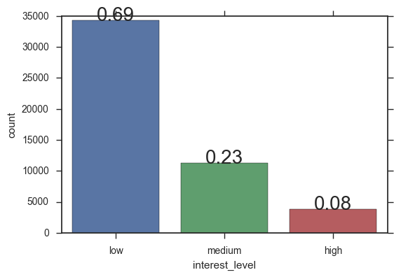

```python
ax = sns.countplot(x="interest_level", data=train_df, order=['low', 'medium', 'high'])
total = float(len(train_df))
for p in ax.patches:
    height = p.get_height()
    ax.text(p.get_x()+p.get_width()/2.,height + 3, '{:1.2f}'.format(height/total), size = 20, ha="center")
plt.show()
```

- interest_level은 69% Low, 23% Medium, 8% High
- 모델 학습할 때 클래스 간의 비율을 맞추기 위해 oversampling / undersampling 필요할 수 있음.

### 2-2 price

```python
train_df.groupby('interest_level').mean()
```

| interest_level | bathrooms | bedrooms | latitude | listing_id | longitude | price |
| --- | --- | --- | --- | --- | --- | --- |
| high | 1.116176 | 1.546496 | 40.748007 | 7.017844e+06 | -73.964613 | 2700.293045 |
| low | 1.238741 | 1.514759 | 40.739504 | 7.026373e+06 | -73.951667 | 4176.599142 |
| medium | 1.163906 | 1.622050 | 40.745567 | 7.019098e+06 | -73.965033 | 3158.767388 |

```
[(0, 300000)]
```

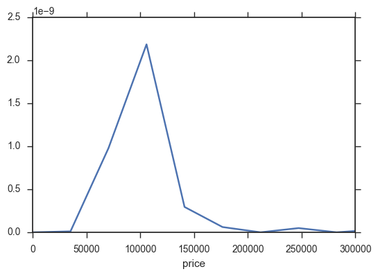

```python
sns.distplot(train_df['price'], hist=False).set(xlim=(0, 300000))
```

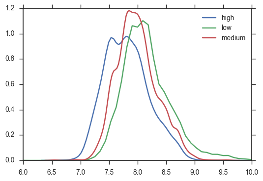

```python
for l, g in train_df.groupby('interest_level'):
    sns.kdeplot(np.log(g['price']), label=l, cumulative = False).set(xlim=(6, 10))
```

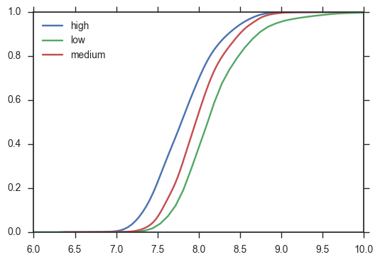

```python
for l, g in train_df.groupby('interest_level'):
    sns.kdeplot(np.log(g['price']), label=l, cumulative = True).set(xlim=(6, 10))
```

- 가격이 저렴할 수록 interest level이 높다. (cumulative density function, https://ko.wikipedia.org/wiki/%EB%88%84%EC%A0%81_%EB%B6%84%ED%8F%AC_%ED%95%A8%EC%88%98)

### 2-3 bathrooms

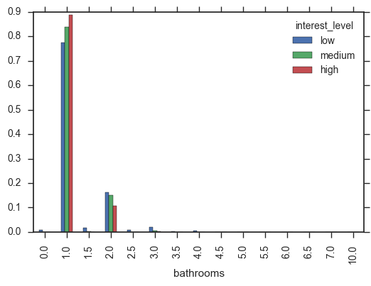

```python
bathrooms = train_df.groupby(['bathrooms', 'interest_level'])['bathrooms'].count().unstack('interest_level')
bathrooms /= bathrooms.sum()
bathrooms.fillna(0)[['low', 'medium', 'high']].plot(kind='bar')
plt.show()
```

- 화장실은 대체로 1개이고, 침실은 0-2개인 경우가 많다.
- 화장실이 1개일 때 상대적으로 high일 가능성이 크고, 화장실이 2개일 때는 high일 가능성이 적다. 나머지 경우 low일 가능성이 크다.

```python
np.cumsum(bathrooms.fillna(0))
```

| interest_level bathrooms | high | low | medium |
| --- | --- | --- | --- |
| 0.0 | 0.000260 | 0.008925 | 0.000534 |
| 1.0 | 0.889294 | 0.784243 | 0.840146 |
| 1.5 | 0.889294 | 0.801890 | 0.843708 |
| 2.0 | 0.995311 | 0.964240 | 0.993944 |
| 2.5 | 0.995311 | 0.972232 | 0.994211 |
| 3.0 | 0.998958 | 0.991804 | 0.999555 |
| 3.5 | 0.998958 | 0.993846 | 0.999555 |
| 4.0 | 1.000000 | 0.998221 | 1.000000 |
| 4.5 | 1.000000 | 0.999067 | 1.000000 |
| 5.0 | 1.000000 | 0.999650 | 1.000000 |
| 5.5 | 1.000000 | 0.999796 | 1.000000 |
| 6.0 | 1.000000 | 0.999912 | 1.000000 |
| 6.5 | 1.000000 | 0.999942 | 1.000000 |
| 7.0 | 1.000000 | 0.999971 | 1.000000 |
| 10.0 | 1.000000 | 1.000000 | 1.000000 |

```
[(0, 3)]
```

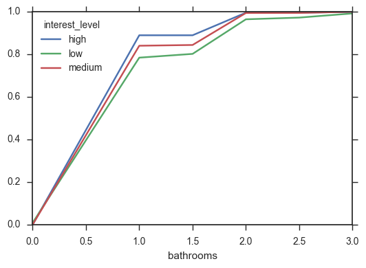

```python
np.cumsum(bathrooms.fillna(0)).plot(kind='line').set(xlim=(0, 3))
```

## 2-4 bedrooms

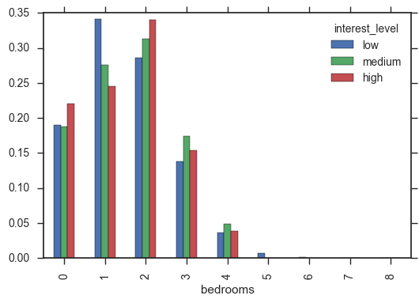

```python
bedrooms = train_df.groupby(['bedrooms', 'interest_level'])['bedrooms'].count().unstack('interest_level')
bedrooms /= bedrooms.sum()
bedrooms[['low', 'medium', 'high']].plot(kind='bar')
plt.show()
```

- 침실이 0, 2개일 때 high일 가능성이 크다.
- 침실이 1개일 때, 그리고 5개 이상일 때 low일 가능성이 크다.
- 침실이 3, 4개일 때 medium일 가능성이 크다.

```
[(0, 4)]
```

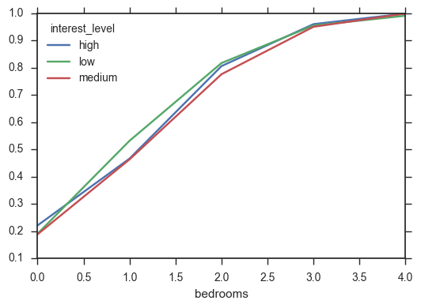

```python
np.cumsum(bedrooms.fillna(0)).plot(kind='line').set(xlim=(0, 4))
```

## 2-5 created

```python
train_df['created'] = pd.to_datetime(train_df['created'])
train_df['week'] = train_df['created'].dt.week
train_df['hour'] = (train_df['created'].dt.hour - 5) % 24 # 동부 표준시는 UTC-05:00 이다.
train_df['weekday'] = train_df['created'].dt.weekday

test_df['created'] = pd.to_datetime(test_df['created'])
test_df['week'] = test_df['created'].dt.week
test_df['hour'] = (test_df['created'].dt.hour - 5) % 24 # 동부 표준시는 UTC-05:00 이다.
test_df['weekday'] = test_df['created'].dt.weekday
```

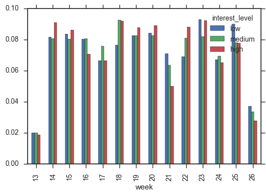

```python
weeks = train_df.groupby(['week', 'interest_level'])['week'].count().unstack('interest_level')
weeks /= weeks.sum()
weeks[['low', 'medium', 'high']].plot(kind='bar')
plt.show()
```

- 주별로 차이가 있지만 그 차이가 미미하다.

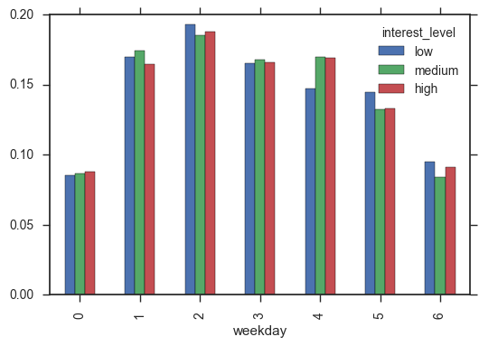

```python
weekdays = train_df.groupby(['weekday', 'interest_level'])['weekday'].count().unstack('interest_level')
weekdays /= weekdays.sum()
weekdays[['low', 'medium', 'high']].plot(kind='bar')
plt.show()
```

- weekday가 0이면 월요일, 1이면 화요일, ..., 6이면 일요일이다.
- 요일에 대한 분포에는 약간의 차이는 있지만 미미하다.

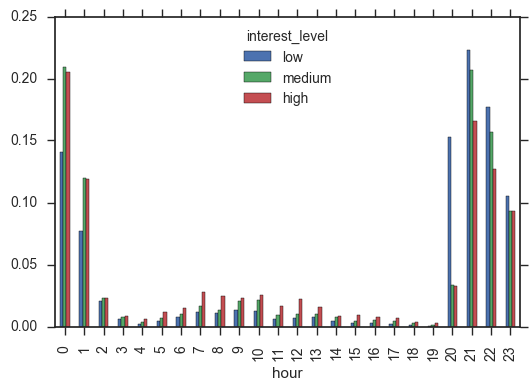

```python
hours = train_df.groupby(['hour', 'interest_level'])['hour'].count().unstack('interest_level').fillna(0)
hours /= hours.sum()
hours[['low', 'medium', 'high']].plot(kind='bar')
plt.show()
```

- 시간에 대한 분포에 차이가 있음.
- 20-23시, 특히 20시에 게시된 글은 low일 가능성이 높다. 낮에 게시된 글은 high일 가능성이 높다.

```
[(0, 23)]
```

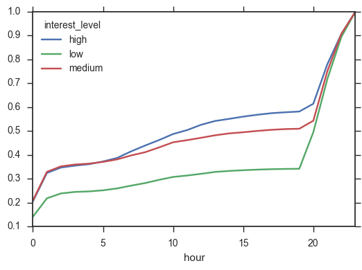

```python
np.cumsum(hours.fillna(0)).plot(kind='line').set(xlim=(0, 23))
```

## 2-6 photos, features & descriptions

```python
train_df.loc[:, 'num_photos'] = train_df.loc[:, 'photos'].apply(len)
train_df.loc[:, 'num_features'] = train_df.loc[:, 'features'].apply(len)
train_df.loc[:, 'num_words'] = train_df.loc[:, 'description'].apply(lambda x: len(x.split(' ')))

test_df.loc[:, 'num_photos'] = test_df.loc[:, 'photos'].apply(len)
test_df.loc[:, 'num_features'] = test_df.loc[:, 'features'].apply(len)
test_df.loc[:, 'num_words'] = test_df.loc[:, 'description'].apply(lambda x: len(x.split(' ')))
```

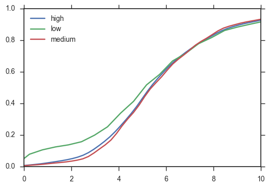

```python
for l, g in train_df.groupby('interest_level'):
    sns.kdeplot(g['num_photos'], label=l, cumulative = True).set(xlim=(0, 10))
```

- 세 분포가 사진이 5개 이하일 때 차이가 있다.

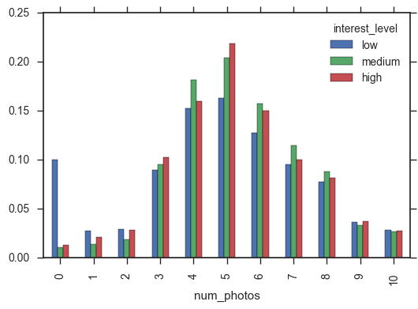

```python
photos = train_df.groupby(['num_photos', 'interest_level'])['num_photos'].count().unstack('interest_level').fillna(0)
photos /= photos.sum()
photos.ix[:10, ['low', 'medium', 'high']].plot(kind='bar')
plt.show()
```

- 사진이 0개이면 low일 가능성이 아주 크고, 4-8개이면 low일 가능성이 적다. 특히, 5개일 때 high일 가능성이 아주 높다.

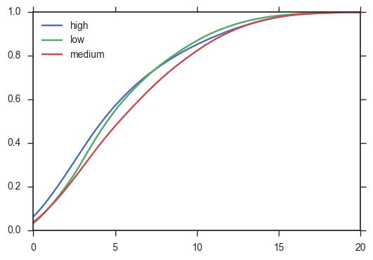

```python
for l, g in train_df.groupby('interest_level'):
    sns.kdeplot(g['num_features'], label=l, cumulative = True).set(xlim=(0, 20))
```

- 세 분포가 특징이 10개 이하일 때 차이가 있다.

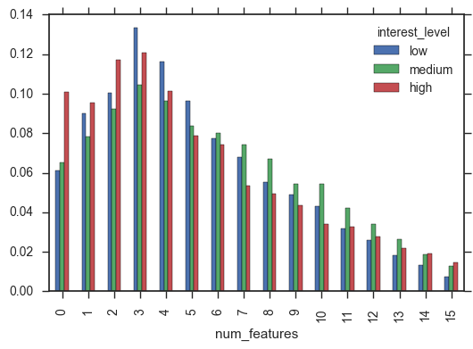

```python
features = train_df.groupby(['num_features', 'interest_level'])['num_features'].count().unstack('interest_level').fillna(0)
features /= features.sum()
features.ix[:15, ['low', 'medium', 'high']].plot(kind='bar')
plt.show()
```

- 대체로 특징이 적을 때, 0-2개일 때 high일 가능성이 크다.
- 특징이 3-5개일 때 low일 가능성이 크다.
- 특징이 6개 이상이면 medium일 가능성이 크다.

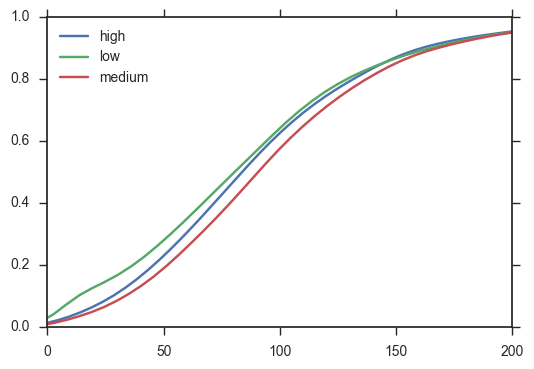

```python
for l, g in train_df.groupby('interest_level'):
    sns.kdeplot(g['num_words'], label=l, cumulative = True).set(xlim=(0, 200))
```

- num_words 개수가 아주 적을 때 약간의 차이가 있다.

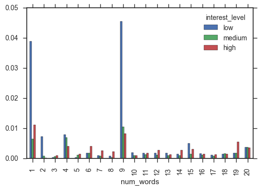

```python
words = train_df.groupby(['num_words', 'interest_level'])['num_words'].count().unstack('interest_level').fillna(0)
words /= words.sum()
words.ix[:20, ['low', 'medium', 'high']].plot(kind='bar')
plt.show()
```

- 개수가 1, 9개일 때 low일 가능성이 아주 크나, 그외의 경우 차이가 미미하다.

```python
### Quantitative substitute of Interest Level
train_df['interest'] = np.where(train_df.interest_level=='low', 0,
                                  np.where(train_df.interest_level=='medium', 1, 2))
```

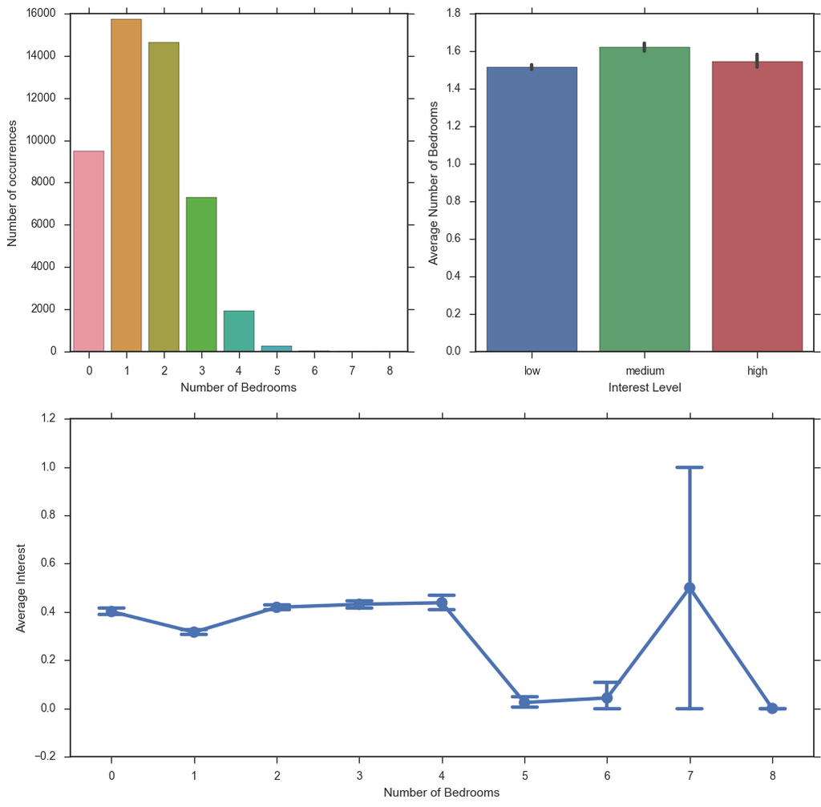

```python
### Bedrooms graphs
fig = plt.figure(figsize=(12,12))

### Number of occurrences
sns.countplot(train_df.bedrooms, ax = plt.subplot(221));
plt.xlabel('Number of Bedrooms');
plt.ylabel('Number of occurrences');

### Average number of Bedrooms per Interest Level
sns.barplot(x='interest_level', y='bedrooms', data=train_df, order=['low', 'medium', 'high'],
            ax = plt.subplot(222));
plt.xlabel('Interest Level');
plt.ylabel('Average Number of Bedrooms');

### Average interest for every number of bedrooms
sns.pointplot(x="bedrooms", y="interest", data=train_df, ax = plt.subplot(212), capsize=.3);
plt.xlabel('Number of Bedrooms');
plt.ylabel('Average Interest');
```

```python
### Most advertised buildings
train_df.building_id.value_counts().nlargest(10)
```

```
0                                   8286
96274288c84ddd7d5c5d8e425ee75027     275
11e1dec9d14b1a9e528386a2504b3afc     215
80a120d6bc3aba97f40fee8c2204524b     213
bb8658a3e432fb62a440615333376345     212
f68bf347f99df026f4faad43cc604048     191
c94301249b8c09429d329864d58e5b82     167
ce6d18bf3238e668b2bf23f4110b7b67     165
57ef86c28a8ae482dc3a3c3af28e8e48     159
128d4af0683efc5e1eded8dc8044d5e3     153
Name: building_id, dtype: int64
```

```python
### Convertion to Python Date
train_df.created = pd.to_datetime(train_df.created, format='%Y-%m-%d %H:%M:%S')
```

```python
### New Month, Day of Week and Hour Features
train_df['month'] = train_df.created.dt.month
train_df['day_of_week'] = train_df.created.dt.weekday_name

test_df['month'] = test_df.created.dt.month
test_df['day_of_week'] = test_df.created.dt.weekday_name
```

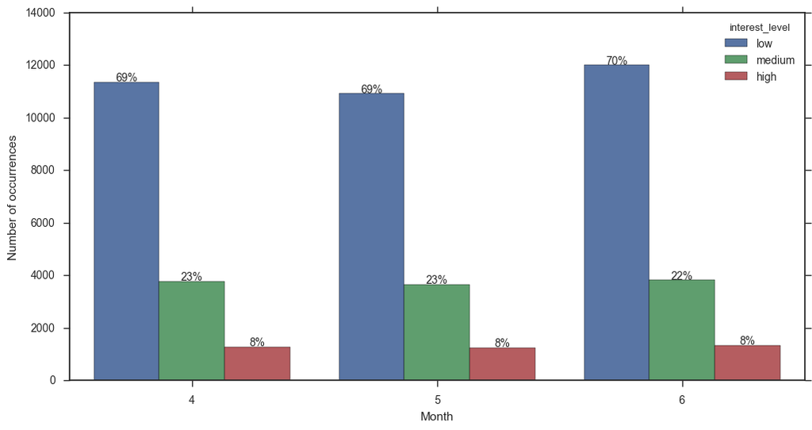

```python
### Iterest per month
fig = plt.figure(figsize=(12,6))
ax = sns.countplot(x="month", hue="interest_level", hue_order=['low', 'medium', 'high'],
                   data=train_df);
plt.xlabel('Month');
plt.ylabel('Number of occurrences')

### Adding percents over bars
height = [p.get_height() for p in ax.patches]
ncol = int(len(height)/3)
total = [height[i] + height[i + ncol] + height[i + 2*ncol] for i in range(ncol)] * 3
for i, p in enumerate(ax.patches):
    ax.text(p.get_x()+p.get_width()/2,
            height[i] + 50,
            '{:1.0%}'.format(height[i]/total[i]),
            ha="center")
```

```python
### 15 most popular Display Addresses
train_df.display_address.value_counts().nlargest(15)
```

```
Broadway             438
East 34th Street     355
Second Avenue        349
Wall Street          332
West 37th Street     287
West Street          258
First Avenue         244
Gold Street          241
Washington Street    237
York Avenue          228
John Street          214
Water Street         214
East 39th Street     200
East 89th Street     195
West 54th Street     193
Name: display_address, dtype: int64
```

## 2-7 longitude / latitude

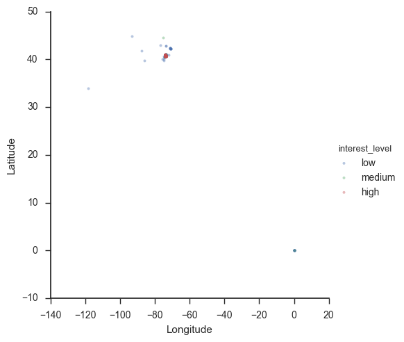

```python
### Rent interest graph of New-York
sns.lmplot(x="longitude", y="latitude", fit_reg=False, hue='interest_level',
           hue_order=['low', 'medium', 'high'], size=5, scatter_kws={'alpha':0.4,'s':8},
           data=train_df);
plt.xlabel('Longitude');
plt.ylabel('Latitude');
```

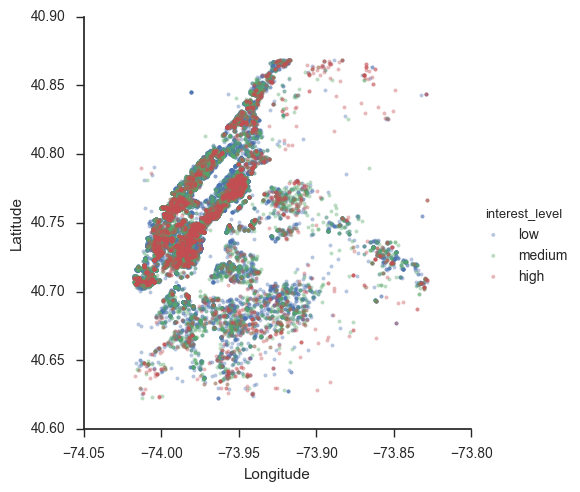

```python
### Rent interest graph of New-York
sns.lmplot(x="longitude", y="latitude", fit_reg=False, hue='interest_level',
           hue_order=['low', 'medium', 'high'], size=5, scatter_kws={'alpha':0.4,'s':8},
           data=train_df[(train_df.longitude>train_df.longitude.quantile(0.005))
                           &(train_df.longitude<train_df.longitude.quantile(0.995))
                           &(train_df.latitude>train_df.latitude.quantile(0.005))
                           &(train_df.latitude<train_df.latitude.quantile(0.995))]);
plt.xlabel('Longitude');
plt.ylabel('Latitude');
```

[figure not shown]

## 2-8 Manger_ID

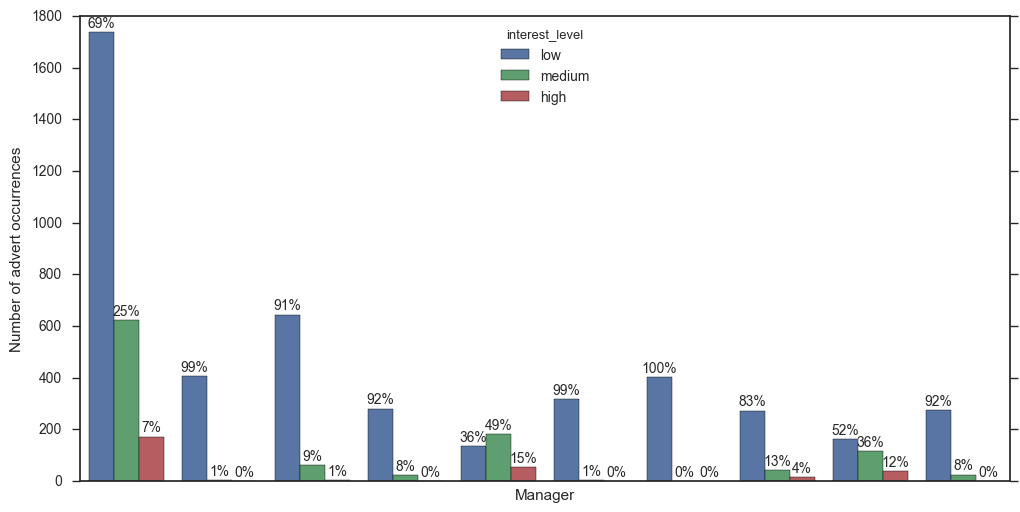

```python
### Let's get a list of top 10 managers
top10managers = train_df.manager_id.value_counts().nlargest(10).index.tolist()

### ...and plot number of different Interest Level rental adverts for each of them
fig = plt.figure(figsize=(12,6))
ax = sns.countplot(x="manager_id", hue="interest_level",
                   data=train_df[train_df.manager_id.isin(top10managers)]);
plt.xlabel('Manager');
plt.ylabel('Number of advert occurrences');

### Manager_ids are too long. Let's remove them
plt.tick_params(
    axis='x',          # changes apply to the x-axis
    which='both',      # both major and minor ticks are affected
    bottom='off',      # ticks along the bottom edge are off
    top='off',         # ticks along the top edge are off
    labelbottom='off');

### Adding percents over bars
height = [0 if np.isnan(p.get_height()) else p.get_height() for p in ax.patches]
ncol = int(len(height)/3)
total = [height[i] + height[i + ncol] + height[i + 2*ncol] for i in range(ncol)] * 3
for i, p in enumerate(ax.patches):
    ax.text(p.get_x()+p.get_width()/2,
            height[i] + 20,
            '{:1.0%}'.format(height[i]/total[i]),
            ha="center")
```

```python
train_df['log_price'] = np.log(train_df['price'])
train_df['log_num_photos'] = np.log(train_df['num_photos'])
train_df['log_num_features'] = np.log(train_df['num_features'])
train_df['log_num_words'] = np.log(train_df['num_words'])
```

## 2-9 Pair Plot

```python
train_df.info()
```

```
<class 'pandas.core.frame.DataFrame'>
Int64Index: 49352 entries, 10 to 99994
Data columns (total 28 columns):
bathrooms           49352 non-null float64
bedrooms            49352 non-null int64
building_id         49352 non-null object
created             49352 non-null datetime64[ns]
description         49352 non-null object
display_address     49352 non-null object
features            49352 non-null object
interest_level      49352 non-null object
latitude            49352 non-null float64
listing_id          49352 non-null int64
longitude           49352 non-null float64
manager_id          49352 non-null object
photos              49352 non-null object
price               49352 non-null int64
street_address      49352 non-null object
week                49352 non-null int64
hour                49352 non-null int64
weekday             49352 non-null int64
num_photos          49352 non-null int64
num_features        49352 non-null int64
num_words           49352 non-null int64
interest            49352 non-null int64
month               49352 non-null int64
day_of_week         49352 non-null object
log_price           49352 non-null float64
log_num_photos      49352 non-null float64
log_num_features    49352 non-null float64
log_num_words       49352 non-null float64
dtypes: datetime64[ns](1), float64(7), int64(11), object(9)
memory usage: 10.9+ MB
```

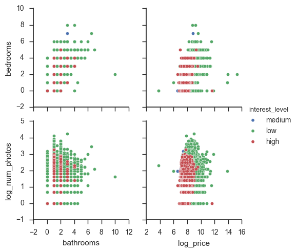

```python
g = sns.pairplot(train_df, hue="interest_level",
                 x_vars=["bathrooms", "log_price"],
                 y_vars=["bedrooms", "log_num_photos"])
g
```

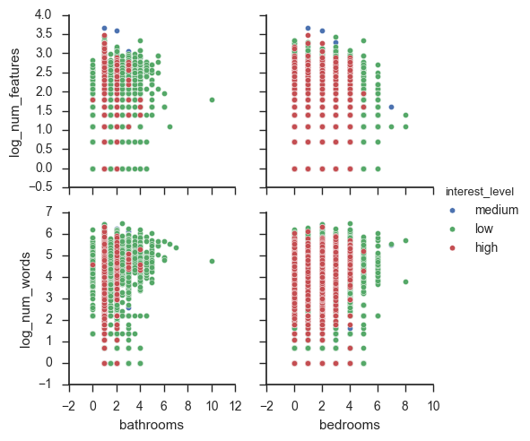

```python
g2 = sns.pairplot(train_df, hue="interest_level",
                 x_vars=["bathrooms", "bedrooms"],
                 y_vars=["log_num_features", "log_num_words"])
g2
```

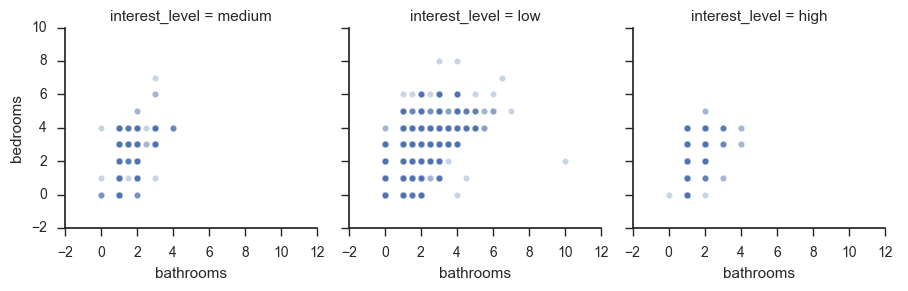

```python
kws = dict(s=20, alpha=.3, edgecolor="w")
sns.FacetGrid(train_df, col="interest_level", size=3) \
   .map(plt.scatter, "bathrooms", "bedrooms", **kws) \
   .add_legend()
plt.show()
```

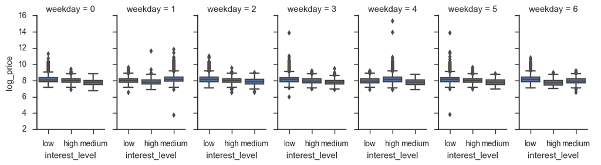

```python
#0, 월요일, 6, 일요일
kws = dict(s=50, alpha=.5, edgecolor="w")
sns.FacetGrid(train_df, size=3, aspect=.5, col="weekday", hue_order=['low', 'medium', 'high']) \
            .map(sns.boxplot, "interest_level", "log_price") \
            .add_legend()
```

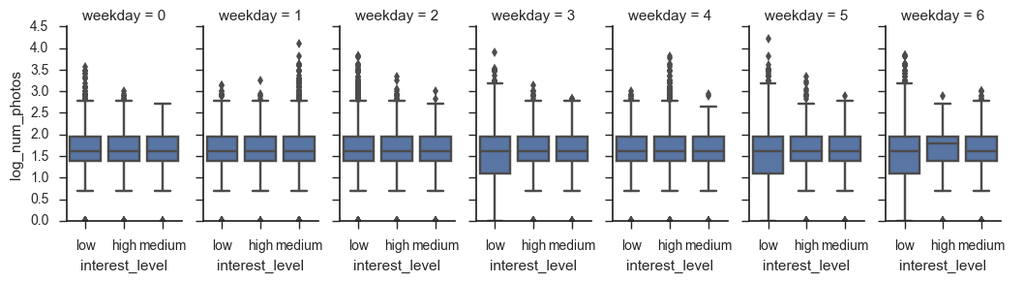

```python
#0, 월요일, 6, 일요일
kws = dict(s=50, alpha=.5, edgecolor="w")
sns.FacetGrid(train_df, size=3, aspect=.5, col="weekday", hue_order=['low', 'medium', 'high']) \
            .map(sns.boxplot, "interest_level", "log_num_photos") \
            .add_legend()
```

## 3. Modeling

### 3-1 변수 추가 및 싱글 모델

```python
#basic features
train_df['created'] = pd.to_datetime(train_df['created'])
train_df['week'] = train_df['created'].dt.week
train_df['hour'] = (train_df['created'].dt.hour - 5) % 24 # 동부 표준시는 UTC-05:00 이다.
train_df['weekday'] = train_df['created'].dt.weekday

test_df['created'] = pd.to_datetime(test_df['created'])
test_df['week'] = test_df['created'].dt.week
test_df['hour'] = (test_df['created'].dt.hour - 5) % 24 # 동부 표준시는 UTC-05:00 이다.
test_df['weekday'] = test_df['created'].dt.weekday

train_df.loc[:, 'num_photos'] = train_df.loc[:, 'photos'].apply(len)
train_df.loc[:, 'num_features'] = train_df.loc[:, 'features'].apply(len)
train_df.loc[:, 'num_words'] = train_df.loc[:, 'description'].apply(lambda x: len(x.split(' ')))

test_df.loc[:, 'num_photos'] = test_df.loc[:, 'photos'].apply(len)
test_df.loc[:, 'num_features'] = test_df.loc[:, 'features'].apply(len)
test_df.loc[:, 'num_words'] = test_df.loc[:, 'description'].apply(lambda x: len(x.split(' ')))

### Convertion to Python Date
train_df.created = pd.to_datetime(train_df.created, format='%Y-%m-%d %H:%M:%S')

### New Month, Day of Week and Hour Features
train_df['month'] = train_df.created.dt.month
train_df['day_of_week'] = train_df.created.dt.weekday_name

test_df['month'] = test_df.created.dt.month
test_df['day_of_week'] = test_df.created.dt.weekday_name

train_df["price_t"] =train_df["price"]/train_df["bedrooms"]
test_df["price_t"] = test_df["price"]/test_df["bedrooms"]
```

```python
train_df.info()
```

```
<class 'pandas.core.frame.DataFrame'>
Int64Index: 49352 entries, 10 to 99994
Data columns (total 29 columns):
bathrooms           49352 non-null float64
bedrooms            49352 non-null int64
building_id         49352 non-null object
created             49352 non-null datetime64[ns]
description         49352 non-null object
display_address     49352 non-null object
features            49352 non-null object
interest_level      49352 non-null object
latitude            49352 non-null float64
listing_id          49352 non-null int64
longitude           49352 non-null float64
manager_id          49352 non-null object
photos              49352 non-null object
price               49352 non-null int64
street_address      49352 non-null object
week                49352 non-null int64
hour                49352 non-null int64
weekday             49352 non-null int64
num_photos          49352 non-null int64
num_features        49352 non-null int64
num_words           49352 non-null int64
interest            49352 non-null int64
month               49352 non-null int64
day_of_week         49352 non-null object
log_price           49352 non-null float64
log_num_photos      49352 non-null float64
log_num_features    49352 non-null float64
log_num_words       49352 non-null float64
price_t             49352 non-null float64
dtypes: datetime64[ns](1), float64(8), int64(11), object(9)
memory usage: 11.3+ MB
```

```python
# 원래 있던 original값들과 새로만든 feature를 넣어 feature_to_use 리스트 만듬
features_to_use=["bathrooms", "bedrooms", "latitude", "longitude", "price", "price_t", "num_photos", "num_features", "num_words", "week", "hour", "weekday", "month", "listing_id"]
```

```python
train_df.head()
```

[output not shown]

```python
# train data 의 수만큼의 list를 만듬
index=list(range(train_df.shape[0]))
random.shuffle(index) # 값 셔플
a=[np.nan]*len(train_df) # 데이터 수만큼 리스트 만들고
b=[np.nan]*len(train_df)
c=[np.nan]*len(train_df)
```

```python
# 데이터를 5등분할 계획
# 매니저id를 key로 하는 building_level을 만듦
for i in range(5):
    building_level={}
    for j in train_df['manager_id'].values:
        building_level[j]=[0,0,0]
    test_index=index[int((i*train_df.shape[0])/5):int(((i+1)*train_df.shape[0])/5)]
    train_index=list(set(index).difference(test_index))
    for j in train_index:
        temp=train_df.iloc[j]
        if temp['interest_level']=='low':
            building_level[temp['manager_id']][0]+=1
        if temp['interest_level']=='medium':
            building_level[temp['manager_id']][1]+=1
        if temp['interest_level']=='high':
            building_level[temp['manager_id']][2]+=1
    for j in test_index:
        temp=train_df.iloc[j]
        if sum(building_level[temp['manager_id']])!=0:
            a[j]=building_level[temp['manager_id']][0]*1.0/sum(building_level[temp['manager_id']])
            b[j]=building_level[temp['manager_id']][1]*1.0/sum(building_level[temp['manager_id']])
            c[j]=building_level[temp['manager_id']][2]*1.0/sum(building_level[temp['manager_id']])
train_df['manager_level_low']=a
train_df['manager_level_medium']=b
train_df['manager_level_high']=c
```

```python
len(a)
```

```
49352
```

```python
train_df.shape
```

```
(49352, 32)
```

```python
train_df.head()
```

|  | bathrooms | bedrooms | building_id | created | description | display_address | features | interest_level | latitude | listing_id | ... | month | day_of_week | log_price | log_num_photos | log_num_features | log_num_words | price_t | manager_level_low | manager_level_medium | manager_level_high |
| --- | --- | --- | --- | --- | --- | --- | --- | --- | --- | --- | --- | --- | --- | --- | --- | --- | --- | --- | --- | --- | --- |
| 10 | 1.5 | 3 | 53a5b119ba8f7b61d4e010512e0dfc85 | 2016-06-24 07:54:24 | A Brand New 3 Bedroom 1.5 bath ApartmentEnjoy ... | Metropolitan Avenue | [] | medium | 40.7145 | 7211212 | ... | 6 | Friday | 8.006368 | 1.609438 | -inf | 4.553877 | 1000.0 | 0.768116 | 0.231884 | 0.000000 |
| 10000 | 1.0 | 2 | c5c8a357cba207596b04d1afd1e4f130 | 2016-06-12 12:19:27 |  | Columbus Avenue | [Doorman, Elevator, Fitness Center, Cats Allow... | low | 40.7947 | 7150865 | ... | 6 | Sunday | 8.606119 | 2.397895 | 1.609438 | 2.197225 | 2732.5 | 1.000000 | 0.000000 | 0.000000 |
| 100004 | 1.0 | 1 | c3ba40552e2120b0acfc3cb5730bb2aa | 2016-04-17 03:26:41 | Top Top West Village location, beautiful Pre-w... | W 13 Street | [Laundry In Building, Dishwasher, Hardwood Flo... | high | 40.7388 | 6887163 | ... | 4 | Sunday | 7.955074 | 2.079442 | 1.386294 | 4.543295 | 2850.0 | 0.570093 | 0.373832 | 0.056075 |
| 100007 | 1.0 | 1 | 28d9ad350afeaab8027513a3e52ac8d5 | 2016-04-18 02:22:02 | Building Amenities - Garage - Garden - fitness... | East 49th Street | [Hardwood Floors, No Fee] | low | 40.7539 | 6888711 | ... | 4 | Monday | 8.094073 | 1.098612 | 0.693147 | 4.382027 | 3275.0 | 0.801242 | 0.142857 | 0.055901 |
| 100013 | 1.0 | 4 | 0 | 2016-04-28 01:32:41 | Beautifully renovated 3 bedroom flex 4 bedroom... | West 143rd Street | [Pre-War] | low | 40.8241 | 6934781 | ... | 4 | Thursday | 8.116716 | 1.098612 | 0.000000 | 4.219508 | 837.5 | 1.000000 | 0.000000 | 0.000000 |

5 rows × 32 columns

```python
# 이번엔 train데이터를 통해 집계한 매니저에 대한 'interest level별 count정보'로 test데이터의 'manager에 대한 interest level별 비율정보'을 구함
a=[]
b=[]
c=[]
building_level={}
for j in train_df['manager_id'].values:
    building_level[j]=[0,0,0]
for j in range(train_df.shape[0]):
    temp=train_df.iloc[j]
    if temp['interest_level']=='low':
        building_level[temp['manager_id']][0]+=1
    if temp['interest_level']=='medium':
        building_level[temp['manager_id']][1]+=1
    if temp['interest_level']=='high':
        building_level[temp['manager_id']][2]+=1

for i in test_df['manager_id'].values:
    if i not in building_level.keys():
        a.append(np.nan)
        b.append(np.nan)
        c.append(np.nan)
    else:
        a.append(building_level[i][0]*1.0/sum(building_level[i]))
        b.append(building_level[i][1]*1.0/sum(building_level[i]))
        c.append(building_level[i][2]*1.0/sum(building_level[i]))
test_df['manager_level_low']=a
test_df['manager_level_medium']=b
test_df['manager_level_high']=c
```

```python
keys = ('77f81a0a8af6db8349587acefd1b533f', '32ca7125de78102ba9ee144a63acc20a')
{k: building_level[k] for k in keys}
```

```
{'32ca7125de78102ba9ee144a63acc20a': [11, 7, 1],
 '77f81a0a8af6db8349587acefd1b533f': [56, 24, 7]}
```

```python
test_df.head()
```

|  | bathrooms | bedrooms | building_id | created | description | display_address | features | latitude | listing_id | longitude | ... | weekday | num_photos | num_features | num_words | month | day_of_week | price_t | manager_level_low | manager_level_medium | manager_level_high |
| --- | --- | --- | --- | --- | --- | --- | --- | --- | --- | --- | --- | --- | --- | --- | --- | --- | --- | --- | --- | --- | --- |
| 0 | 1.0 | 1 | 79780be1514f645d7e6be99a3de696c5 | 2016-06-11 05:29:41 | Large with awesome terrace--accessible via bed... | Suffolk Street | [Elevator, Laundry in Building, Laundry in Uni... | 40.7185 | 7142618 | -73.9865 | ... | 5 | 8 | 6 | 78 | 6 | Saturday | 2950.0 | 0.458333 | 0.333333 | 0.208333 |
| 1 | 1.0 | 2 | 0 | 2016-06-24 06:36:34 | Prime Soho - between Bleecker and Houston - Ne... | Thompson Street | [Pre-War, Dogs Allowed, Cats Allowed] | 40.7278 | 7210040 | -74.0000 | ... | 4 | 3 | 3 | 35 | 6 | Friday | 1425.0 | 1.000000 | 0.000000 | 0.000000 |
| 100 | 1.0 | 1 | 3dbbb69fd52e0d25131aa1cd459c87eb | 2016-06-03 04:29:40 | New York chic has reached a new level ... | 101 East 10th Street | [Doorman, Elevator, No Fee] | 40.7306 | 7103890 | -73.9890 | ... | 4 | 6 | 3 | 333 | 6 | Friday | 3758.0 | 0.000000 | 1.000000 | 0.000000 |
| 1000 | 1.0 | 2 | 783d21d013a7e655bddc4ed0d461cc5e | 2016-06-11 06:17:35 | Step into this fantastic new Construction in t... | South Third Street\r | [Roof Deck, Balcony, Elevator, Laundry in Buil... | 40.7109 | 7143442 | -73.9571 | ... | 5 | 6 | 10 | 204 | 6 | Saturday | 1650.0 | 0.245902 | 0.393443 | 0.360656 |
| 100000 | 2.0 | 2 | 6134e7c4dd1a98d9aee36623c9872b49 | 2016-04-12 05:24:17 | ~Take a stroll in Central Park, enjoy the ente... | Midtown West, 8th Ave | [Common Outdoor Space, Cats Allowed, Dogs Allo... | 40.7650 | 6860601 | -73.9845 | ... | 1 | 7 | 14 | 174 | 4 | Tuesday | 2450.0 | 0.597222 | 0.319444 | 0.083333 |

5 rows × 26 columns

```python
#위에서 애써만든 매니저 평가정보를 여기에서 feature에 포함시킴
features_to_use.append('manager_level_low')
features_to_use.append('manager_level_medium')
features_to_use.append('manager_level_high')
```

```python
features_to_use
```

```
['bathrooms',
 'bedrooms',
 'latitude',
 'longitude',
 'price',
 'price_t',
 'num_photos',
 'num_features',
 'num_words',
 'week',
 'hour',
 'weekday',
 'month',
 'listing_id',
 'manager_level_low',
 'manager_level_medium',
 'manager_level_high']
```

```python
# 범주형 데이터를 넣는 과정
categorical = ["display_address", "manager_id", "building_id", "street_address"]
for f in categorical:
        if train_df[f].dtype=='object':
            #print(f)
            lbl = preprocessing.LabelEncoder() #범주형 변수를 사용하기 위해 팩터화시키는것
            lbl.fit(list(train_df[f].values) + list(test_df[f].values))
            train_df[f] = lbl.transform(list(train_df[f].values))
            test_df[f] = lbl.transform(list(test_df[f].values))
            features_to_use.append(f)
```

## LabelEncoder() ?

- Encode labels with value between 0 and n_classes-1.

```python
le = preprocessing.LabelEncoder()
```

```python
le.fit([1, 2, 2, 6])
```

```
LabelEncoder()
```

```python
le.transform([1, 1, 2, 6])
```

```
array([0, 0, 1, 2])
```

```python
le = preprocessing.LabelEncoder()
le.fit(["paris", "paris", "tokyo", "amsterdam"])
list(le.classes_)
```

```
['amsterdam', 'paris', 'tokyo']
```

```python
le.transform(["tokyo", "tokyo", "paris"])
```

```
array([2, 2, 1])
```

```python
train_df[['display_address','manager_id','building_id','street_address']].head()
```

|  | display_address | manager_id | building_id | street_address |
| --- | --- | --- | --- | --- |
| 10 | 12282 | 1568 | 3797 | 23484 |
| 10000 | 9080 | 1988 | 8986 | 23680 |
| 100004 | 13719 | 3733 | 8889 | 9827 |
| 100007 | 10866 | 282 | 1848 | 14237 |
| 100013 | 15072 | 2618 | 0 | 19227 |

```python
features_to_use
```

```
['bathrooms',
 'bedrooms',
 'latitude',
 'longitude',
 'price',
 'price_t',
 'num_photos',
 'num_features',
 'num_words',
 'week',
 'hour',
 'weekday',
 'month',
 'listing_id',
 'manager_level_low',
 'manager_level_medium',
 'manager_level_high',
 'display_address',
 'manager_id',
 'building_id',
 'street_address']
```

```python
train_df[f].values
```

```
array([23484, 23680,  9827, ..., 14787, 15771, 11802])
```

```python
test_df[f].values
```

```
array([24898,  5492,   541, ..., 15281, 14244, 24425])
```

```python
len(features_to_use)
```

```
21
```

## Scikit-Learn의 문서 전처리 기능

### Scikit-Learn 의 feature_extraction.text 서브 패키지는 다음과 같은 문서 전처리용 클래스 제공

1) CountVectorizer

```
- 문서 집합으로부터 단어의 수를 세어 카운트 행렬을 만듦
```

2) TfidfVectorizer

```
- 문서 집합으로부터 단어의 수를 세고 TF-IDF 방식으로 단어의 가중치를 조정한 카운트 행렬을 만듦.
```

#### Tf-idf?

- TF-IDF는 단어 빈도와 역문서 빈도의 곱.
  - 단어 빈도 tf(t,d)의 경우, 이 값을 산출하는 가장 간단한 방법은 단순히 문서 내에 나타나는 해당 단어의 총 빈도수를 사용하는 것, scikit-learn에서는 log(빈도(boolean, 한번이라도 나타나면 1, 아니면 0) +1)으로 계산.
  - 역문서 빈도는 한 단어가 문서 집합 전체에서 얼마나 공통적으로 나타나는지를 나타내는 값이다. 전체 문서의 수를 해당 단어를 포함한 문서의 수로 나눈 뒤 로그를 취하여 얻을 수 있음

[figure not shown]

```python
# original데이터의 features컬럼을 tfidf 팩터화
train_df['features'] = train_df["features"].apply(lambda x: " ".join(["_".join(i.split(" ")) for i in x]))
test_df['features'] = test_df["features"].apply(lambda x: " ".join(["_".join(i.split(" ")) for i in x]))
print(train_df["features"].head())
tfidf = CountVectorizer(stop_words='english', max_features=200)
tr_sparse = tfidf.fit_transform(train_df["features"])
te_sparse = tfidf.transform(test_df["features"])
```

```
10
10000     Doorman Elevator Fitness_Center Cats_Allowed D...
100004    Laundry_In_Building Dishwasher Hardwood_Floors...
100007                               Hardwood_Floors No_Fee
100013                                              Pre-War
Name: features, dtype: object
```

```python
print(tr_sparse.toarray().mean(axis=0)[1:10])
```

```
[ 0.00028368  0.00030394  0.0008105   0.00036473  0.0003242   0.00026341
  0.00038499  0.00018236  0.00022289]
```

```python
# xgb에 넣기위해 자료구조를 만듬
train_X = sparse.hstack([train_df[features_to_use], tr_sparse]).tocsr()
test_X = sparse.hstack([test_df[features_to_use], te_sparse]).tocsr()
print(type(train_X))
target_num_map = {'high':0, 'medium':1, 'low':2}
train_y = np.array(train_df['interest_level'].apply(lambda x: target_num_map[x]))
print(train_X.shape, test_X.shape)
```

```
<class 'scipy.sparse.csr.csr_matrix'>
(49352, 221) (74659, 221)
```

```python
print(train_X[0:10,].todense())
```

```
[[  1.5      3.      40.7145 ...,   0.       0.       0.    ]
 [  1.       2.      40.7947 ...,   0.       0.       0.    ]
 [  1.       1.      40.7388 ...,   0.       0.       0.    ]
 ...,
 [  2.       1.      40.7427 ...,   0.       0.       0.    ]
 [  1.       1.      40.8234 ...,   0.       0.       0.    ]
 [  2.       4.      40.7278 ...,   0.       0.       0.    ]]
```

```python
column_1 = train_df[features_to_use].columns.tolist()
column_2 = tfidf.get_feature_names()
column_1.extend(column_2)

#print(column_1)
#train_X_df = pd.DataFrame(train_X.toarray())
#train_X_df.columns = column_1
#train_X_df.head()
#test_X_df = pd.DataFrame(test_X.toarray())
#test_X_df.columns = column_1
#test_X_df.head()
```

### ML - ensemble 기법

- ensemble 모형이란 주어진 데이터를 이용하여 여러 개의 서로 다른 예측 모형을 생성한 후, 이러한 예측 모형의 예측 결과를 종합하여 하나의 최종 예측결과를 도출해 내는 방법
- ensemble를 하는 이유?
  - 다양한 모델이 문제 공간의 다른 측면을 보면서 각기 다른 방식으로 잘못된 부분이 있다고 가정 (모델 별로 약점을 보완)
  - 모델의 분산 및 오버 피팅을 줄이기 위해서
- 앙상블의 대표적인 기법은 배깅과 부스팅
- 배깅(Bootstrap Aggregating, Bagging)이란
  - 테스트 데이터 샘플링(Bootstrap) 통해 여러개의 테스트 데이터를 만들고,
  - 각 테스트 데이터를 이용해 여러개의 weak learner 를 만든다.
  - 최종적으로 각 learner 의 예측결과를 평균내서 종합(aggregate)한다.
- 부스팅이란(Boosting)이란
  - 부스트래핑된 테스트 데이터로 여러개의 weak learner 들을 순차적으로(iterative) 만드는데,
  - i번째 learner 는 i-1 번째 learner 가 잘못 예측한 데이터에 가중치를 좀 더 주어서(boosting) 학습한다.
  - 최종적으로 마지막에 생성된 learner 를 이용하여 예측한다.

### Tree model

- 의사결정 트리 학습은 데이터 마이닝에서 일반적으로 사용되는 방법
- 목표는 여러 입력 변수를 기반으로 대상 변수의 값을 예측하는 모델을 만드는 것
- 각 내부 노드는 입력 변수 중 하나에 해당. 해당 입력 변수의 가능한 각 값에 대해 하위에 가장자리가 있음. 각 리프는 루트에서 리프까지의 경로로 표시되는 입력 변수의 값이 주어질 때 대상 변수의 값을 나타냅니다.
- Root Node, Intermediate Node, Terminal Node
- 의사결정나무는 한번 분기 때마다 변수 영역을 두 개로 구분하는 모델, 불순도(impurity) 혹은 불확실성(uncertainty)이 최대한 감소하도록 하는 방향으로 학습, 엔트로피 / 지니 인덱스 기준으로 나무를 분리함
- [엔트로피 / 지니 인덱스](http://www.bogotobogo.com/python/scikit-learn/scikt_machine_learning_Decision_Tree_Learning_Informatioin_Gain_IG_Impurity_Entropy_Gini_Classification_Error.php)

$$ Entropy = -\sum_jp_j\log_2p_j $$$$ Gini = 1-\sum_jp_j^2 $$

[figure not shown]

## 불순도 계산 Example

$$ IG(D_p) = I(D_p) - \frac{N_{left}}{N_p}I(D_{left}) - \frac{N_{right}}{N_p}I(D_{right}) $$

[figure not shown]

### 1) 지니 인덱스

$$ Gini = 1-\sum_jp_j^2 $$

### Case A

$$ A:I_G(D_{left}) = 1 - \left( \left(\frac{30}{40} \right)^2 + \left(\frac{10}{40}\right)^2 \right) = 1 - \left( \frac{9}{16} + \frac{1}{16} \right) = \frac38 = 0.375 $$$$ A:I_G(D_{right}) = 1 - \left( \left(\frac{10}{40}\right)^2 + \left(\frac{30}{40}\right)^2 \right) = 1 - \left(\frac{1}{16}+\frac{9}{16}\right) = \frac38 = 0.375 $$$$ A:I_G = 0.5 - \frac{40}{80} \times 0.375 - \frac{40}{80} \times 0.375 = \color{blue}{0.125} $$

### 2) 엔트로피

$$ Entropy = -\sum_jp_j\log_2p_j $$

### Case A

$$ I_H(D_p) = - \left( 0.5\log_2(0.5) + 0.5\log_2(0.5) \right) = 1 $$$$ A:I_H(D_{left}) = - \left( \frac{30}{40}\log_2 \left(\frac{30}{40} \right) + \frac{10}{40}\log_2 \left(\frac{10}{40} \right) \right) = 0.81 $$$$ A:I_H(D_{right}) = - \left( \frac{10}{40}\log_2 \left(\frac{10}{40} \right) + \frac{30}{40}\log_2 \left(\frac{30}{40} \right) \right) = 0.81 $$$$ A:IG_H = 1 - \frac{40}{80} \times 0.81 - \frac{40}{80} \times 0.81 = \color{blue}{0.19} $$

### Case B

$$ B:I_H(D_{left}) = - \left( \frac{20}{60}\log_2 \left(\frac{20}{60} \right) + \frac{40}{60}\log_2 \left(\frac{40}{60} \right) \right) = 0.92 $$$$ B:I_H(D_{right}) = - \left( \frac{20}{20}\log_2 \left(\frac{20}{20} \right) + 0 \right) = 0 $$$$ B:IG_H = 1 - \frac{60}{80} \times 0.92 - \frac{20}{80} \times 0 = \color{blue}{0.31} $$

### Xgboost

- Boosting 알고리즘 특화 라이브러리 (Extreme Gradient Boosting)

[figure not shown]

- Boosting은 sequential process로 이전 tree 모델로 부터 얻은 정보를 다음 tree를 생성하는데 활용

[figure not shown]

- 다음 tree 모델은 이전 tree 모델에서 오분류(잘못 분류)된 지점에 더 높은 가중치를 줘서 재학습하게 됨
- [Introduction to Boosted Trees](http://xgboost.readthedocs.io/en/latest/model.html)

[Complete Guide to Parameter Tuning in XGBoost (with codes in Python)](https://www.analyticsvidhya.com/blog/2016/03/complete-guide-parameter-tuning-xgboost-with-codes-python/)

```python
#https://flonelin.wordpress.com/2016/07/26/tuning-xgboostextream-gradient-boosting/
def runXGB(train_X, train_y, test_X, test_y=None, feature_names=None, seed_val=0, num_rounds=100):
    param = {}
    param['objective'] = 'multi:softprob'
    param['eta'] = 0.03
    param['max_depth'] = 6
    param['silent'] = 1
    param['num_class'] = 3
    param['eval_metric'] = "mlogloss"
    param['min_child_weight'] = 1
    param['subsample'] = 0.7 # 70프로만 뽑겠다
    param['colsample_bytree'] = 0.7 # 변수 컬럼 비율
    param['seed'] = seed_val # 초기값 설정 랜덤 안되게
    num_rounds = num_rounds

    plst = list(param.items())
    xgtrain = xgb.DMatrix(train_X, label=train_y) # D매트릭스로 바꿔줘야 한다.
    feature_names = xgtrain.feature_names

    # test의 타겟값을 넣은 xgb model
    if test_y is not None:
        xgtest = xgb.DMatrix(test_X, label=test_y)
        watchlist = [ (xgtrain,'train'), (xgtest, 'test') ]
        model = xgb.train(plst, xgtrain, num_rounds, watchlist, early_stopping_rounds=20)
    # test의 타겟값을 넣지 않은 xgb model
    else:
        xgtest = xgb.DMatrix(test_X)
        model = xgb.train(plst, xgtrain, num_rounds)

    pred_test_y = model.predict(xgtest)
    return pred_test_y, model, feature_names
```

```python
cv_scores = []
kf = model_selection.KFold(n_splits=5, shuffle=True, random_state=2016)
for dev_index, val_index in kf.split(range(train_X.shape[0])):
        dev_X, val_X = train_X[dev_index,:], train_X[val_index,:]
        dev_y, val_y = train_y[dev_index], train_y[val_index]
        preds, model, feature_names = runXGB(dev_X, dev_y, val_X, val_y)
        cv_scores.append(log_loss(val_y, preds))
        print(cv_scores)
        break
```

```
Multiple eval metrics have been passed: 'test-mlogloss' will be used for early stopping.

Will train until test-mlogloss hasn't improved in 20 rounds.
[0.60437993390259015]
```

### 변수 중요도 확인

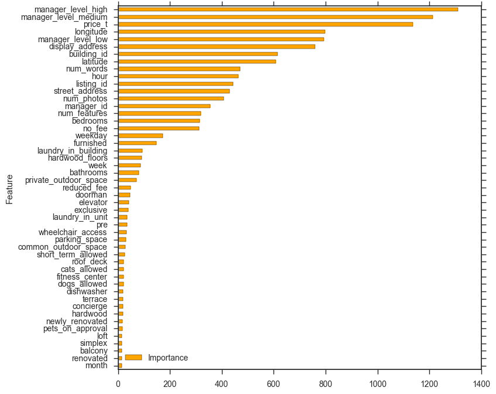

```python
importances = model.get_fscore()

mapper = {'f{0}'.format(i): v for i, v in enumerate(column_1)}
mapped = {mapper[k]: v for k, v in model.get_fscore().items()}
mapped

importance_frame = pd.DataFrame({'Importance': list(mapped.values()), 'Feature': list(mapped.keys())})
importance_frame.sort_values(by = 'Importance', inplace = True, ascending=False)
importance_frame[1:50].sort_values(by = 'Importance').plot(kind = 'barh', x = 'Feature', figsize = (8,8), color = 'orange')
```

```python
preds, model, feature_names = runXGB(train_X, train_y, test_X, num_rounds=100)
out_df = pd.DataFrame(preds)
out_df.columns = ["high", "medium", "low"]
out_df["listing_id"] = test_df.listing_id.values
out_df.to_csv("data/xgb_starter_num_rounds100_sangyeol.csv", index=False)
```

### 첫 번째 제출 (Score 0.60314)

[Submit link](https://www.kaggle.com/c/two-sigma-connect-rental-listing-inquiries/submit)

- 1) Kaggle 사이트에서 처음 제출하시는 분들은 모바일 인증(confirm)을 해야됨
- 2) 그리고 제출하는 대회 약관 동의를 해야함.

[figure not shown]

## 3-2 Stacking

### (Advanced) Stacking or meta-ensembling

- Ref : https://www.kaggle.com/den3b81/better-predictions-stacking-with-votingclassifier
- 대부분의 Kaggle 대회에서 우승자는 대개 스태킹이나 메타 앙상블에 의존
  - 이것은 여러 가지 1 단계 예측 모델을 조합하여 모두를 능가하는 2 단계 모델을 생성하는 기법
- 일반적으로 2 차 수준 모델이 각 1 차 수준 모델의 장점을 최대한 활용하고 데이터 집합의 다른 부분에 약점이 미치는 영향을 완화 할 수 있기 때문에 발생
- 이 작은 실험을 위해 기본 매개 변수화로 훈련 된 4 가지 분류 기준의 예측을 결합. 매개 변수 조정은 하지 않음

```
분류기는 다음과 같습니다 :
1) "엔트로피"기준을 갖는 RandomForestClassifier
2) "gini"기준을 갖는 RandomForestClassifier
3) Sklearn GradientBoostingClassifier
4) XGBoost 분류기
```

```python
train_X = pd.DataFrame(train_X.todense())
test_X = pd.DataFrame(test_X.todense())
```

```python
train_X.head()
```

|  | 0 | 1 | 2 | 3 | 4 | 5 | 6 | 7 | 8 | 9 | ... | 211 | 212 | 213 | 214 | 215 | 216 | 217 | 218 | 219 | 220 |
| --- | --- | --- | --- | --- | --- | --- | --- | --- | --- | --- | --- | --- | --- | --- | --- | --- | --- | --- | --- | --- | --- |
| 0 | 1.5 | 3.0 | 40.7145 | -73.9425 | 3000.0 | 1000.0 | 5.0 | 0.0 | 95.0 | 25.0 | ... | 0.0 | 0.0 | 0.0 | 0.0 | 0.0 | 0.0 | 0.0 | 0.0 | 0.0 | 0.0 |
| 1 | 1.0 | 2.0 | 40.7947 | -73.9667 | 5465.0 | 2732.5 | 11.0 | 5.0 | 9.0 | 23.0 | ... | 0.0 | 0.0 | 0.0 | 0.0 | 0.0 | 0.0 | 0.0 | 0.0 | 0.0 | 0.0 |
| 2 | 1.0 | 1.0 | 40.7388 | -74.0018 | 2850.0 | 2850.0 | 8.0 | 4.0 | 94.0 | 15.0 | ... | 0.0 | 0.0 | 0.0 | 0.0 | 0.0 | 0.0 | 0.0 | 0.0 | 0.0 | 0.0 |
| 3 | 1.0 | 1.0 | 40.7539 | -73.9677 | 3275.0 | 3275.0 | 3.0 | 2.0 | 80.0 | 16.0 | ... | 0.0 | 0.0 | 0.0 | 0.0 | 0.0 | 0.0 | 0.0 | 0.0 | 0.0 | 0.0 |
| 4 | 1.0 | 4.0 | 40.8241 | -73.9493 | 3350.0 | 837.5 | 3.0 | 1.0 | 68.0 | 17.0 | ... | 0.0 | 0.0 | 1.0 | 0.0 | 0.0 | 0.0 | 0.0 | 0.0 | 0.0 | 0.0 |

5 rows × 221 columns

## NaN 결측값 처리

- 일부 알고리즘은 결측값이 있을 경우 모델이 정상적으로 작동하지 않음 (랜덤포레스트)
- Mean, Median 또는 Most frequency value 값으로 넣어주는 것이 가장 쉬운 방법
- 다른 컬럼들을 기준으로 모델(머신러닝)로 결측 값을 처리할 수도 있음.

```python
imp = Imputer(missing_values='NaN', strategy='mean', axis=0)
imp = imp.fit(train_X)
```

```python
train_X_imp = imp.fit_transform(train_X)
test_X_imp = imp.fit_transform(test_X)

train_X_imp
```

```
array([[  1.5   ,   3.    ,  40.7145, ...,   0.    ,   0.    ,   0.    ],
       [  1.    ,   2.    ,  40.7947, ...,   0.    ,   0.    ,   0.    ],
       [  1.    ,   1.    ,  40.7388, ...,   0.    ,   0.    ,   0.    ],
       ...,
       [  1.    ,   1.    ,  40.7601, ...,   0.    ,   0.    ,   0.    ],
       [  1.    ,   0.    ,  40.7066, ...,   0.    ,   0.    ,   0.    ],
       [  1.    ,   2.    ,  40.8699, ...,   0.    ,   0.    ,   0.    ]])
```

```python
# random state for reproducing same results
random_state = 2310

X_train, X_val, y_train, y_val = train_test_split(train_X_imp, train_y, test_size=0.33, random_state = random_state)
```

```python
X_train
```

```
array([[  1.    ,   1.    ,  40.7627, ...,   0.    ,   0.    ,   0.    ],
       [  1.    ,   1.    ,  40.7073, ...,   0.    ,   0.    ,   0.    ],
       [  1.    ,   2.    ,  40.7806, ...,   0.    ,   0.    ,   0.    ],
       ...,
       [  1.    ,   1.    ,  40.6477, ...,   0.    ,   0.    ,   0.    ],
       [  2.    ,   2.    ,  40.7337, ...,   0.    ,   0.    ,   0.    ],
       [  2.    ,   2.    ,  40.8084, ...,   0.    ,   0.    ,   0.    ]])
```

```python
rf1 = RandomForestClassifier(n_estimators=250, criterion='entropy',  n_jobs = -1,  random_state=random_state)
rf1.fit(X_train, y_train)
y_val_pred = rf1.predict_proba(X_val)
log_loss(y_val, y_val_pred)
```

```
0.59202111764706888
```

```python
rf2= RandomForestClassifier(n_estimators=250, criterion='gini',  n_jobs = -1, random_state=random_state)
rf2.fit(X_train, y_train)
y_val_pred = rf2.predict_proba(X_val)
log_loss(y_val, y_val_pred)
```

```
0.58809416146819282
```

```python
gbc = GradientBoostingClassifier(random_state=random_state)
gbc.fit(X_train, y_train)
y_val_pred = gbc.predict_proba(X_val)
log_loss(y_val, y_val_pred)
```

```
0.57197859389908667
```

```python
xgb = xgb.XGBClassifier(seed=random_state)
xgb.fit(X_train, y_train)
y_val_pred = xgb.predict_proba(X_val)
log_loss(y_val, y_val_pred)
```

```
0.57724058775224318
```

### Model Blending

- 여러 모델들의 예측 결과 값을 가지고 모델의 성능을 향상시킬 수 있음
- Soft Voting
  - 각 클래스에 대한 모든 모델의 예상 확률의 가중치 합계를 계산하는 것을 수반.
  - 가중치가 모든 분류 자에 대해 동일하면 확률은 단순히 각 클래스의 평균.
- A) 모델 4개를 동일하게 가중치를 줬을 경우와 B) 성능이 좋은 3번째 모델(gbc)의 가중치를 더 줬을 경우
  - A), B) 모델 성능을 확인

```python
eclf = VotingClassifier(estimators=[
    ('rf1', rf1), ('rf2', rf2), ('gbc', gbc), ('xgb',xgb)], voting='soft')
eclf.fit(X_train, y_train)
y_val_pred = eclf.predict_proba(X_val)
log_loss(y_val, y_val_pred)
```

```
0.57163177141282973
```

```python
eclf = VotingClassifier(estimators=[
    ('rf1', rf1), ('rf2', rf2), ('gbc', gbc), ('xgb',xgb)], voting='soft', weights = [1,1,3,1])
eclf.fit(X_train, y_train)
y_val_pred = eclf.predict_proba(X_val)
log_loss(y_val, y_val_pred)
```

```
0.56958502453184079
```

```python
pred = eclf.predict_proba(test_X_imp)
```

```python
out_df = pd.DataFrame(pred)
out_df.columns = ["high", "medium", "low"]
out_df["listing_id"] = test_df.listing_id.values
out_df.to_csv("data/voting_4.csv", index=False)
```

### 두 번째 제출 (Score 0.57843)

[figure not shown]

## 3-3 Feature engineering

### 변수 추가 (김연민님 자료 참고)

- ref : https://github.com/yeonmin/KaggleTwoSigmaRentHop

```python
def add_feature(df):
    data = df.copy()

    data['date'] = pd.to_datetime(data['created'])
    data['year'] = data['date'].dt.year
    data['month'] = data['date'].dt.month
    data['day'] = data['date'].dt.day
    data['wday'] = data['date'].dt.dayofweek
    data['yday'] = data['date'].dt.dayofyear
    data['hour'] = data['date'].dt.hour
    data["total_days"] =   (data["month"] -4.0)*30 + data["day"] +  data["hour"] /25.0
    data["diff_rank"]= data["total_days"]/data["listing_id"]

    # 사진개수
    data["photo_count"] = data["photos"].apply(len)

    # 가격에 대한 추가 Feature
    data["pricePerBed"] = data['price'] / data['bedrooms']
    data["pricePerBath"] = data['price'] / data['bathrooms']
    data["pricePerRoom"] = data['price'] / (data['bedrooms'] + data['bathrooms'])
    data["price_latitue"] = (data["price"])/ (data["latitude"]+1.0)
    data["price_longtitude"] = (data["price"])/ (data["longitude"]-1.0)
    #data["num_price_by_furniture"] = data["price"] / (data["bathrooms"] + data["bedrooms"])


    # 방에 대한 추가 Feature
    data["bedPerBath"] = data['bedrooms'] / data['bathrooms']
    data["bedPerDiff"] = data['bedrooms'] - data['bathrooms']
    data["num_furniture"] =  data["bathrooms"] + data["bedrooms"]
    data["num_furniture"] = data["num_furniture"].apply(lambda x:  str(x) if float(x)<9.5 else '10')
    data['num_furniture'] = data['num_furniture'].astype('float')

    # https://www.kaggle.com/ogrellier/median-rental-prices-matter/notebook/notebook
    median_prices = data[['price','bedrooms']]
    medians_by_key = median_prices.groupby(by='bedrooms')['price'].median().reset_index()
    medians_by_key.rename(columns={'price': 'median_price_bed'}, inplace=True)
    data = data.merge(medians_by_key, on='bedrooms', how='left')
    data['price_ratio_bed_price_median'] = data['price'] / data['median_price_bed']

    data['zero_building_id'] = data['building_id'].apply(lambda x: 1 if x == '0' else 0)


    # Features/Description Features
    bows = {'nofee': ['no fee', 'no-fee', 'no  fee', 'nofee', 'no_fee'],
            'lowfee': ['reduced_fee', 'low_fee','reduced fee', 'low fee'],
            'furnished': ['furnished'],
            'parquet': ['parquet', 'hardwood'],
            'concierge': ['concierge', 'doorman', 'housekeep','in_super'],
            'prewar': ['prewar', 'pre_war', 'pre war', 'pre-war'],
            'laundry': ['laundry', 'lndry'],
            'health': ['health', 'gym', 'fitness', 'training'],
            'transport': ['train', 'subway', 'transport'],
            'parking': ['parking'],
            'utilities': ['utilities', 'heat water', 'water included']
          }
    for fname, bow in bows.items():
        x1 = data.description.str.lower().apply(lambda x: np.sum([1 for i in bow if i in x]))
        x2 = data.features.apply(lambda x: np.sum([1 for i in bow if i in ' '.join(x).lower()]))
        data['num_'+fname] = ((x1 + x2) > 0).astype(float).values

    return data
```

```python
import random

def manager_level(train,test):
    train_df = train.copy()
    test_df = test.copy()

    index=list(range(train_df.shape[0]))
    random.shuffle(index)
    a=[np.nan]*len(train_df)
    b=[np.nan]*len(train_df)
    c=[np.nan]*len(train_df)

    for i in range(5):
        building_level={}
        for j in train_df['manager_id'].values:
            building_level[j]=[0,0,0]
        test_index=index[int((i*train_df.shape[0])/5):int(((i+1)*train_df.shape[0])/5)]
        train_index=list(set(index).difference(test_index))
        for j in train_index:
            temp=train_df.iloc[j]
            if temp['interest_level']=='low':
                building_level[temp['manager_id']][0]+=1
            if temp['interest_level']=='medium':
                building_level[temp['manager_id']][1]+=1
            if temp['interest_level']=='high':
                building_level[temp['manager_id']][2]+=1
        for j in test_index:
            temp=train_df.iloc[j]
            if sum(building_level[temp['manager_id']])!=0:
                a[j]=building_level[temp['manager_id']][0]*1.0/sum(building_level[temp['manager_id']])
                b[j]=building_level[temp['manager_id']][1]*1.0/sum(building_level[temp['manager_id']])
                c[j]=building_level[temp['manager_id']][2]*1.0/sum(building_level[temp['manager_id']])
    train_df['manager_level_low']=a
    train_df['manager_level_medium']=b
    train_df['manager_level_high']=c

    a=[]
    b=[]
    c=[]
    building_level={}
    for j in train_df['manager_id'].values:
        building_level[j]=[0,0,0]
    for j in range(train_df.shape[0]):
        temp=train_df.iloc[j]
        if temp['interest_level']=='low':
            building_level[temp['manager_id']][0]+=1
        if temp['interest_level']=='medium':
            building_level[temp['manager_id']][1]+=1
        if temp['interest_level']=='high':
            building_level[temp['manager_id']][2]+=1

    for i in test_df['manager_id'].values:
        if i not in building_level.keys():
            a.append(np.nan)
            b.append(np.nan)
            c.append(np.nan)
        else:
            a.append(building_level[i][0]*1.0/sum(building_level[i]))
            b.append(building_level[i][1]*1.0/sum(building_level[i]))
            c.append(building_level[i][2]*1.0/sum(building_level[i]))
    test_df['manager_level_low']=a
    test_df['manager_level_medium']=b
    test_df['manager_level_high']=c

    return train_df,test_df
```

```python
train_df = pd.read_json("./data/train.json")
test_df = pd.read_json('./data/test.json')
```

```python
train_df = add_feature(train_df)
test_df = add_feature(test_df)
```

```python
train_df,test_df = manager_level(train_df,test_df)
```

```python
train_df.info()
```

```
<class 'pandas.core.frame.DataFrame'>
Int64Index: 49352 entries, 0 to 49351
Data columns (total 50 columns):
bathrooms                       49352 non-null float64
bedrooms                        49352 non-null int64
building_id                     49352 non-null object
created                         49352 non-null object
description                     49352 non-null object
display_address                 49352 non-null object
features                        49352 non-null object
interest_level                  49352 non-null object
latitude                        49352 non-null float64
listing_id                      49352 non-null int64
longitude                       49352 non-null float64
manager_id                      49352 non-null object
photos                          49352 non-null object
price                           49352 non-null int64
street_address                  49352 non-null object
date                            49352 non-null datetime64[ns]
year                            49352 non-null int64
month                           49352 non-null int64
day                             49352 non-null int64
wday                            49352 non-null int64
yday                            49352 non-null int64
hour                            49352 non-null int64
total_days                      49352 non-null float64
diff_rank                       49352 non-null float64
photo_count                     49352 non-null int64
pricePerBed                     49352 non-null float64
pricePerBath                    49352 non-null float64
pricePerRoom                    49352 non-null float64
price_latitue                   49352 non-null float64
price_longtitude                49352 non-null float64
bedPerBath                      49195 non-null float64
bedPerDiff                      49352 non-null float64
num_furniture                   49352 non-null float64
median_price_bed                49352 non-null float64
price_ratio_bed_price_median    49352 non-null float64
zero_building_id                49352 non-null int64
num_parquet                     49352 non-null float64
num_parking                     49352 non-null float64
num_utilities                   49352 non-null float64
num_furnished                   49352 non-null float64
num_lowfee                      49352 non-null float64
num_laundry                     49352 non-null float64
num_prewar                      49352 non-null float64
num_nofee                       49352 non-null float64
num_concierge                   49352 non-null float64
num_transport                   49352 non-null float64
num_health                      49352 non-null float64
manager_level_low               48165 non-null float64
manager_level_medium            48165 non-null float64
manager_level_high              48165 non-null float64
dtypes: datetime64[ns](1), float64(29), int64(11), object(9)
memory usage: 19.2+ MB
```

```python
train_df.shape
```

```
(49352, 50)
```

```python
test_df.shape
```

```
(74659, 49)
```

```python
features_to_use=["bathrooms", "bedrooms", "latitude", "longitude",
                 "price", "year", "month", "day", "wday", "yday", "hour", "total_days",
                 "diff_rank", "photo_count", "pricePerBed", "pricePerBath", "pricePerRoom",
                 "price_latitue", "price_longtitude", "bedPerBath", "bedPerDiff", "num_furniture",
                 "median_price_bed", "price_ratio_bed_price_median", "zero_building_id", "num_laundry",
                 "num_transport", "num_parquet", "num_lowfee", "num_health", "num_furnished", "num_concierge",
                 "num_utilities", "num_parking", "num_nofee", "num_prewar",
                 "manager_level_low", "manager_level_medium", "manager_level_high",
                 "listing_id"]
```

```python
train_X = sparse.hstack([train_df[features_to_use], tr_sparse]).tocsr()
test_X = sparse.hstack([test_df[features_to_use], te_sparse]).tocsr()

target_num_map = {'high':0, 'medium':1, 'low':2}
train_y = np.array(train_df['interest_level'].apply(lambda x: target_num_map[x]))
print(train_X.shape, test_X.shape)
```

```
(49352, 240) (74659, 240)
```

```python
train_X = pd.DataFrame(train_X.todense())
test_X = pd.DataFrame(test_X.todense())
```

```python
imp = Imputer(missing_values='NaN', strategy='mean', axis=0)
imp = imp.fit(train_X)
train_X_imp = imp.fit_transform(train_X)
test_X_imp = imp.fit_transform(test_X)
```

```python
# random state for reproducing same results
random_state = 2310

X_train, X_val, y_train, y_val = train_test_split(train_X_imp, train_y, test_size=0.33, random_state = random_state)
```

```python
rf1 = RandomForestClassifier(n_estimators=250, criterion='entropy',  n_jobs = -1,  random_state=random_state)
rf1.fit(X_train, y_train)
y_val_pred = rf1.predict_proba(X_val)
log_loss(y_val, y_val_pred)
```

```
0.56915177651908622
```

```python
rf2= RandomForestClassifier(n_estimators=250, criterion='gini',  n_jobs = -1, random_state=random_state)
rf2.fit(X_train, y_train)
y_val_pred = rf2.predict_proba(X_val)
log_loss(y_val, y_val_pred)
```

```
0.57246527803261582
```

```python
gbc = GradientBoostingClassifier(random_state=random_state)
gbc.fit(X_train, y_train)
y_val_pred = gbc.predict_proba(X_val)
log_loss(y_val, y_val_pred)
```

```
0.56285674972993416
```

```python
import xgboost as xgb
xgb = xgb.XGBClassifier(seed=random_state)
xgb.fit(X_train, y_train)
y_val_pred = xgb.predict_proba(X_val)
log_loss(y_val, y_val_pred)
```

```
0.56889289112291519
```

```python
eclf = VotingClassifier(estimators=[
    ('rf1', rf1), ('rf2', rf2), ('gbc', gbc), ('xgb',xgb)], voting='soft', weights = [1,1,3,1])
eclf.fit(X_train, y_train)
y_val_pred = eclf.predict_proba(X_val)
log_loss(y_val, y_val_pred)
```

```
0.55729646983005687
```

```python
pred = eclf.predict_proba(test_X_imp)

out_df = pd.DataFrame(pred)
out_df.columns = ["high", "medium", "low"]
out_df["listing_id"] = test_df.listing_id.values
out_df.to_csv("data/voting_varadd_4.csv", index=False)
```

### 세 번째 제출 (Score 0.56789)

[figure not shown]

# Kagglebreak!!!

### - 튜토리얼을 통해 캐글(Kaggle)을 뽀갰지만 내용이 아쉬운 분은 스터디로 놀러오심 같이 참여하며 배울 수 있습니다.

### 1) 캐글뽀개기 스터디 : 실습형 데이터 분석 스터디 그룹 / [캐글뽀개기](https://www.facebook.com/groups/kagglebreak)

### 2) 싸이그래머 스터디 : 통계와 프로그래밍, 요리, 엠티, 여행을 즐기는 심리학도 - "소설 습작클럽처럼, 아마추어 화가들의 화실처럼" [싸이그래머](https://www.facebook.com/groups/psygrammer/)

### 3) 싸이버스 : 싸이-* 시리즈 그룹의 소식을 전하는 허브페이지. [싸이버스](https://www.facebook.com/thepsybus)

### 캐글뽀개기 그룹 정보 : 스터디 자료 - https://github.com/kagglebreak

### 스터디 명칭 / 요일 / github주소

```
- 캐글즐기기 매주 수요일 (파트4 종료, https://github.com/KaggleBreak/analyticstool) / 데이터 과학 스터디
- 텐서뽀개기 격주 화요일 (6/27일 파트1 시작,  https://github.com/KaggleBreak/tensorbreak) / 텐서플로우 스터디
- 워킹캐글 주말 (8/26일 파트2 시작, https://github.com/KaggleBreak/walkingkaggle) / 캐글 대회 도전 스터디
```